# Evaluating Winner’s Curse methods

In this document, we intend to investigate the following key questions, assuming a fixed array of $10^6$ SNPs:

- When should I be concerned about Winner’s Curse or about my association estimates being more extreme than their corresponding true effect sizes?
- If I adjust SNP-trait association estimates using a Winner’s Curse method, how much should I expect this to improve the association estimates of significant SNPs?
- If I do use a Winner’s Curse method, which one should I use?

We first focus on a quantitative trait in which SNP effect sizes follow a *normal* distribution.

### 1. When is Winner’s Curse a problem?

In this section, we look at the average number of significant SNPs, the average proportion of these significant SNPs that have association estimates more extreme than their true effect size and the average MSE of significant SNPs at two different thresholds; the common genome-wide significance threshold of $5 \times 10^{-8}$ and a higher threshold of $5 \times 10^{-4}$. We consider these properties under certain combinations of values for the following parameters:

1. sample size - `n_samples`
2. heritability - `h2`
3. polygenicity, i.e. proportion of effect SNPs - `prop_effect`
4. selection coefficient - `S`

The 24 different combinations that we will investigate throughout this document are detailed below:

| Scenario | n_samples | h2 | prop_effect | S |
| --- | --- | --- | --- | --- |
| 1 | 30,000 | 0.3 | 0.010 | -1 |
| 2 | 300,000 | 0.3 | 0.010 | -1 |
| 3 | 30,000 | 0.8 | 0.010 | -1 |
| 4 | 300,000 | 0.8 | 0.010 | -1 |
| 5 | 30,000 | 0.3 | 0.001 | -1 |
| 6 | 300,000 | 0.3 | 0.001 | -1 |
| 7 | 30,000 | 0.8 | 0.001 | -1 |
| 8 | 300,000 | 0.8 | 0.001 | -1 |
| 9 | 30,000 | 0.3 | 0.010 | 0 |
| 10 | 300,000 | 0.3 | 0.010 | 0 |
| 11 | 30,000 | 0.8 | 0.010 | 0 |
| 12 | 300,000 | 0.8 | 0.010 | 0 |

| Scenario | n_samples | h2 | prop_effect | S |
| --- | --- | --- | --- | --- |
| 13 | 30,000 | 0.3 | 0.001 | 0 |
| 14 | 300,000 | 0.3 | 0.001 | 0 |
| 15 | 30,000 | 0.8 | 0.001 | 0 |
| 16 | 300,000 | 0.8 | 0.001 | 0 |
| 17 | 30,000 | 0.3 | 0.010 | 1 |
| 18 | 300,000 | 0.3 | 0.010 | 1 |
| 19 | 30,000 | 0.8 | 0.010 | 1 |
| 20 | 300,000 | 0.8 | 0.010 | 1 |
| 21 | 30,000 | 0.3 | 0.001 | 1 |
| 22 | 300,000 | 0.3 | 0.001 | 1 |
| 23 | 30,000 | 0.8 | 0.001 | 1 |
| 24 | 300,000 | 0.8 | 0.001 | 1 |

$~$ $~$ $~$

Running the code provided in `nsig_prop_bias_100sim.R`, we obtain the following results. Note that `prop_x` refers to the proportion of significant SNPs which have been found to be significantly overestimated, i.e. those SNPs in which $\left| \hat\beta_{i} \right| > \left| \beta_{i} \right| + 1.96\cdot\sigma_{i}$.

| Scenario | n_samples | h2 | prop_effect | S | n_sig 5e-8 | prop_bias 5e-8 | prop_x 5e-8 | mse 5e-8 | n_sig 5e-4 | prop_bias 5e-4 | prop_x 5e-4 | mse 5e-4 | sd(n_sig) 5e-8 | sd(prop_bias) 5e-8 | sd(prop_x) 5e-8 | sd(mse) 5e-8 | sd(n_sig) 5e-4 | sd(prop_bias) 5e-4 | sd(prop_x) 5e-4 | sd(mse) 5e-4 |
| --- | --- | --- | --- | --- | --- | --- | --- | --- | --- | --- | --- | --- | --- | --- | --- | --- | --- | --- | --- | --- |
| 1 | 30,000 | 0.3 | 0.010 | -1 | 0.70 | 1.0000 | 0.9000 | 0.001573 | 610.99 | 0.9996 | 0.9165 | 0.001919 | 0.745 | 0.0000 | 0.2950 | 0.001234 | 23.070 | 0.0008 | 0.0108 | 0.000105 |
| 2 | 300,000 | 0.3 | 0.010 | -1 | 848.63 | 0.7619 | 0.0895 | 0.000022 | 3201.35 | 0.7461 | 0.2083 | 0.000049 | 18.145 | 0.0142 | 0.0103 | 0.000002 | 47.967 | 0.0070 | 0.0071 | 0.000003 |
| 3 | 30,000 | 0.8 | 0.010 | -1 | 31.85 | 0.9804 | 0.4020 | 0.000598 | 1089.98 | 0.9597 | 0.5647 | 0.001194 | 5.208 | 0.0280 | 0.0834 | 0.000198 | 35.158 | 0.0053 | 0.0136 | 0.000060 |
| 4 | 300,000 | 0.8 | 0.010 | -1 | 2760.68 | 0.6284 | 0.0484 | 0.000017 | 5349.44 | 0.6393 | 0.1305 | 0.000035 | 30.091 | 0.0084 | 0.0038 | 0.000001 | 43.729 | 0.0069 | 0.0045 | 0.000002 |
| 5 | 30,000 | 0.3 | 0.001 | -1 | 86.90 | 0.7591 | 0.0892 | 0.000214 | 772.12 | 0.8957 | 0.6724 | 0.001474 | 6.317 | 0.0437 | 0.0290 | 0.000054 | 25.913 | 0.0090 | 0.0140 | 0.000088 |
| 6 | 300,000 | 0.3 | 0.001 | -1 | 568.70 | 0.5509 | 0.0330 | 0.000016 | 1211.96 | 0.7303 | 0.4300 | 0.000099 | 14.074 | 0.0225 | 0.0078 | 0.000002 | 24.787 | 0.0128 | 0.0127 | 0.000006 |
| 7 | 30,000 | 0.8 | 0.001 | -1 | 276.26 | 0.6273 | 0.0464 | 0.000168 | 986.59 | 0.8043 | 0.5276 | 0.001198 | 10.413 | 0.0271 | 0.0123 | 0.000027 | 26.682 | 0.0117 | 0.0138 | 0.000075 |
| 8 | 300,000 | 0.8 | 0.001 | -1 | 727.10 | 0.5257 | 0.0287 | 0.000016 | 1326.17 | 0.7068 | 0.3971 | 0.000093 | 12.491 | 0.0171 | 0.0061 | 0.000001 | 24.072 | 0.0127 | 0.0105 | 0.000005 |
| 9 | 30,000 | 0.3 | 0.010 | 0 | 1.45 | 1.0000 | 0.8610 | 0.001661 | 627.16 | 0.9985 | 0.8888 | 0.001825 | 1.298 | 0.0000 | 0.2745 | 0.005559 | 25.180 | 0.0015 | 0.0128 | 0.000090 |
| 10 | 300,000 | 0.3 | 0.010 | 0 | 882.45 | 0.7297 | 0.0807 | 0.000012 | 3054.78 | 0.7427 | 0.2176 | 0.000046 | 18.435 | 0.0152 | 0.0098 | 0.000001 | 45.422 | 0.0070 | 0.0066 | 0.000002 |
| 11 | 30,000 | 0.8 | 0.010 | 0 | 48.06 | 0.9509 | 0.2908 | 0.000245 | 1110.51 | 0.9407 | 0.5435 | 0.001091 | 6.350 | 0.0301 | 0.0645 | 0.000050 | 29.205 | 0.0068 | 0.0123 | 0.000060 |
| 12 | 300,000 | 0.8 | 0.010 | 0 | 2586.78 | 0.6204 | 0.0477 | 0.000011 | 5032.06 | 0.6455 | 0.1375 | 0.000032 | 32.771 | 0.0096 | 0.0038 | 0.000000 | 45.218 | 0.0062 | 0.0046 | 0.000002 |
| 13 | 30,000 | 0.3 | 0.001 | 0 | 88.32 | 0.7254 | 0.0774 | 0.000116 | 755.09 | 0.8953 | 0.6820 | 0.001491 | 6.377 | 0.0480 | 0.0279 | 0.000025 | 22.799 | 0.0097 | 0.0131 | 0.000077 |
| 14 | 300,000 | 0.3 | 0.001 | 0 | 531.27 | 0.5560 | 0.0334 | 0.000012 | 1183.18 | 0.7402 | 0.4407 | 0.000100 | 12.431 | 0.0215 | 0.0074 | 0.000001 | 27.843 | 0.0121 | 0.0091 | 0.000006 |
| 15 | 30,000 | 0.8 | 0.001 | 0 | 257.44 | 0.6234 | 0.0473 | 0.000106 | 953.63 | 0.8130 | 0.5449 | 0.001202 | 8.936 | 0.0276 | 0.0120 | 0.000013 | 23.262 | 0.0100 | 0.0115 | 0.000070 |
| 16 | 300,000 | 0.8 | 0.001 | 0 | 691.46 | 0.5268 | 0.0301 | 0.000013 | 1301.33 | 0.7114 | 0.4040 | 0.000092 | 13.526 | 0.0185 | 0.0066 | 0.000001 | 29.469 | 0.0110 | 0.0123 | 0.000005 |
| 17 | 30,000 | 0.3 | 0.010 | 1 | 2.55 | 0.9941 | 0.7339 | 0.000610 | 641.18 | 0.9966 | 0.8643 | 0.001777 | 1.623 | 0.0405 | 0.3034 | 0.000674 | 25.497 | 0.0022 | 0.0126 | 0.000107 |
| 18 | 300,000 | 0.3 | 0.010 | 1 | 919.28 | 0.7031 | 0.0706 | 0.000010 | 2902.71 | 0.7313 | 0.2228 | 0.000046 | 15.799 | 0.0142 | 0.0079 | 0.000001 | 38.290 | 0.0086 | 0.0073 | 0.000003 |
| 19 | 30,000 | 0.8 | 0.010 | 1 | 68.13 | 0.9178 | 0.2410 | 0.000198 | 1141.84 | 0.9208 | 0.5196 | 0.001047 | 7.795 | 0.0370 | 0.0486 | 0.000087 | 29.135 | 0.0077 | 0.0144 | 0.000063 |
| 20 | 300,000 | 0.8 | 0.010 | 1 | 2433.27 | 0.6105 | 0.0462 | 0.000009 | 4634.50 | 0.6464 | 0.1461 | 0.000032 | 30.705 | 0.0107 | 0.0047 | 0.000000 | 48.828 | 0.0078 | 0.0046 | 0.000002 |
| 21 | 30,000 | 0.3 | 0.001 | 1 | 93.15 | 0.7056 | 0.0684 | 0.000096 | 742.12 | 0.8944 | 0.6949 | 0.001509 | 5.960 | 0.0428 | 0.0273 | 0.000015 | 23.899 | 0.0102 | 0.0140 | 0.000080 |
| 22 | 300,000 | 0.3 | 0.001 | 1 | 482.94 | 0.5516 | 0.0329 | 0.000009 | 1124.74 | 0.7510 | 0.4635 | 0.000103 | 12.742 | 0.0244 | 0.0072 | 0.000001 | 24.808 | 0.0116 | 0.0117 | 0.000006 |
| 23 | 30,000 | 0.8 | 0.001 | 1 | 244.29 | 0.6120 | 0.0448 | 0.000089 | 917.81 | 0.8199 | 0.5673 | 0.001249 | 9.237 | 0.0272 | 0.0142 | 0.000010 | 25.125 | 0.0110 | 0.0137 | 0.000084 |
| 24 | 300,000 | 0.8 | 0.001 | 1 | 632.74 | 0.5336 | 0.0294 | 0.000010 | 1235.79 | 0.7201 | 0.4192 | 0.000094 | 14.730 | 0.0194 | 0.0071 | 0.000001 | 25.984 | 0.0121 | 0.0112 | 0.000005 |

$~$ $~$ $~$

★ It is important to note here that for scenarios 1, 9 and 17, very few significant SNPs are detected on average. In some instances, we may even find that no SNPs are deemed significant at a threshold of $5 \times 10^{-8}$. We must keep this observation in mind going forward as we investigate the performance of methods under these three scenarios.

For both thresholds, the average number of significant SNPs increases as sample size increases, as expected. It also increases with heritability. However, the effect of changing `prop_effect` is more interesting. Decreasing the proportion of effect SNPs from 0.01 to 0.001 results in the number of significant SNPs increasing for a sample size of 30,000 while we witness the number of SNPs passing the genome-wide significance threshold decreasing for a larger sample size of 300,000.

Furthermore, increasing sample size and increasing heritability from 0.3 to 0.8 all tend to decrease the fraction of significant SNPs whose estimates are more extreme than their true effect size. Decreasing polygenicity from 0.01 to 0.001 also has this same effect at a significance threshold of $5 \times 10^{-8}$.

As sample size increases from 30,000 to 300,000 in all scenarios, `prop_x`, the proportion of significant SNPs which have been found to be significantly overestimated, decreases. This is a strong indicator that as the value of `n_samples` increases, we expect the bias induced by Winner’s Curse to be less of a problem among significant SNPs. However, this could also be due to the fact that as sample size increases, the number of significant SNPs passing the genome-wide significance threshold of `5e-8` also increases.

In order to gain a better insight into the information detailed in the above table, we simulate a single set of GWAS summary statistics and plot $z$ vs $\text{bias}$ in which $\text{bias} = \hat\beta - \beta$ for each of the 24 different scenarios. On all figures, the bright red line corresponds to the significance threshold of $5 \times 10^{-8}$ while the darker red line relates to $5 \times 10^{-4}$. The points corresponding to SNPs which are *significantly* overestimated and are significant at a threshold of $5 \times 10^{-4}$ are coloured in navy .

$~$ $~$ $~$ $~$

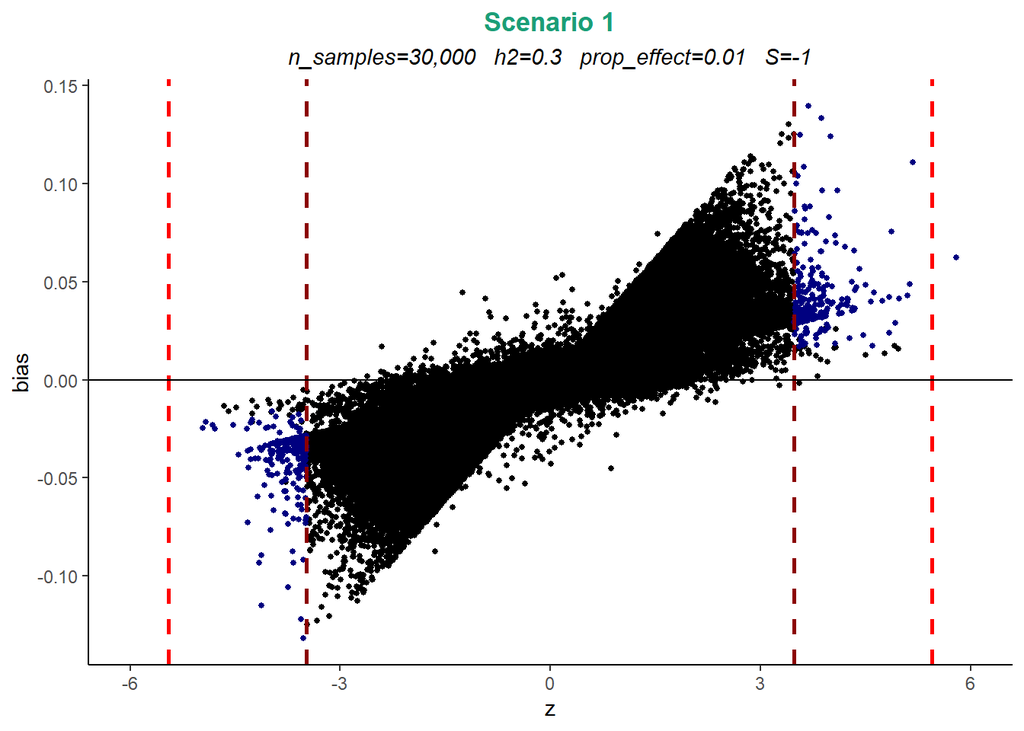

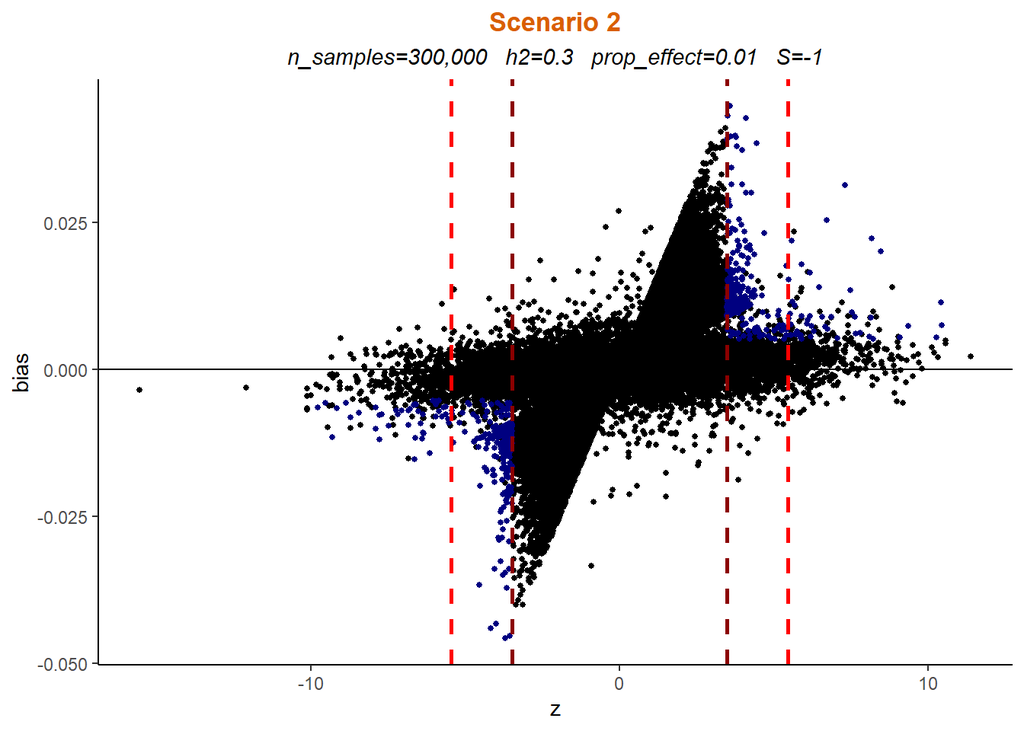

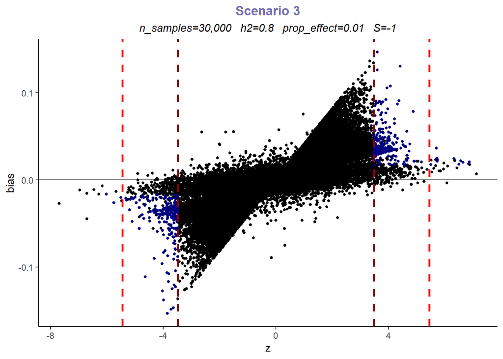

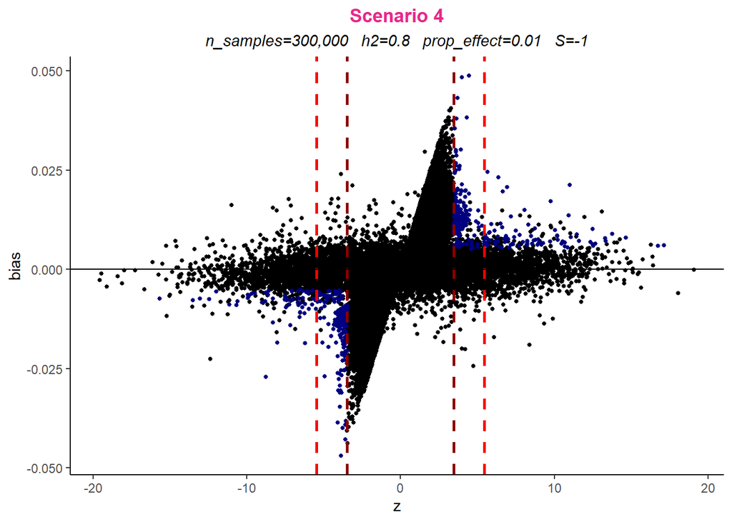

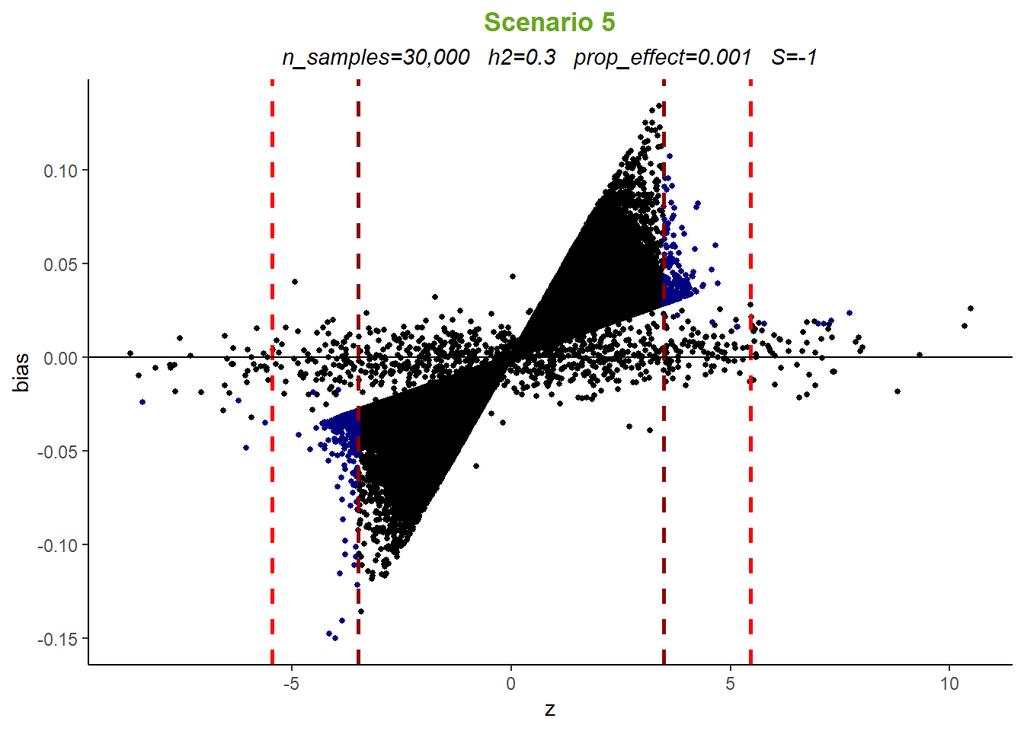

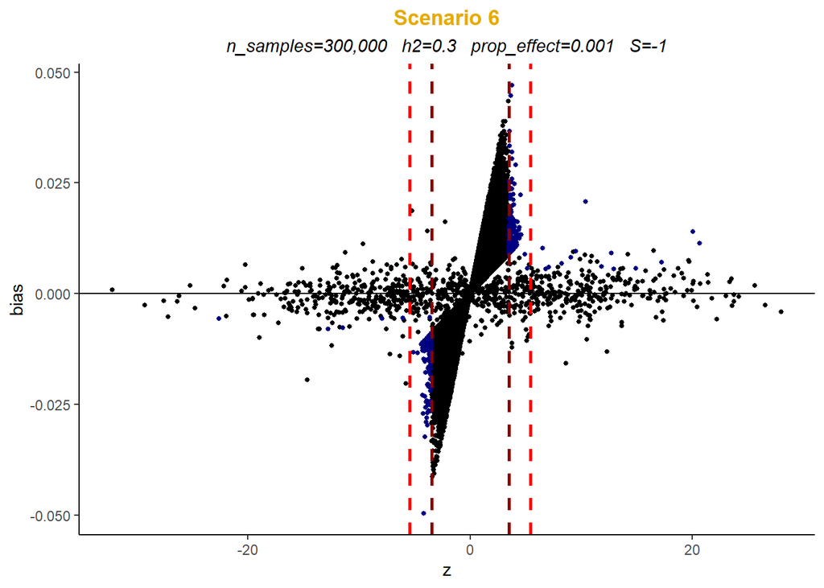

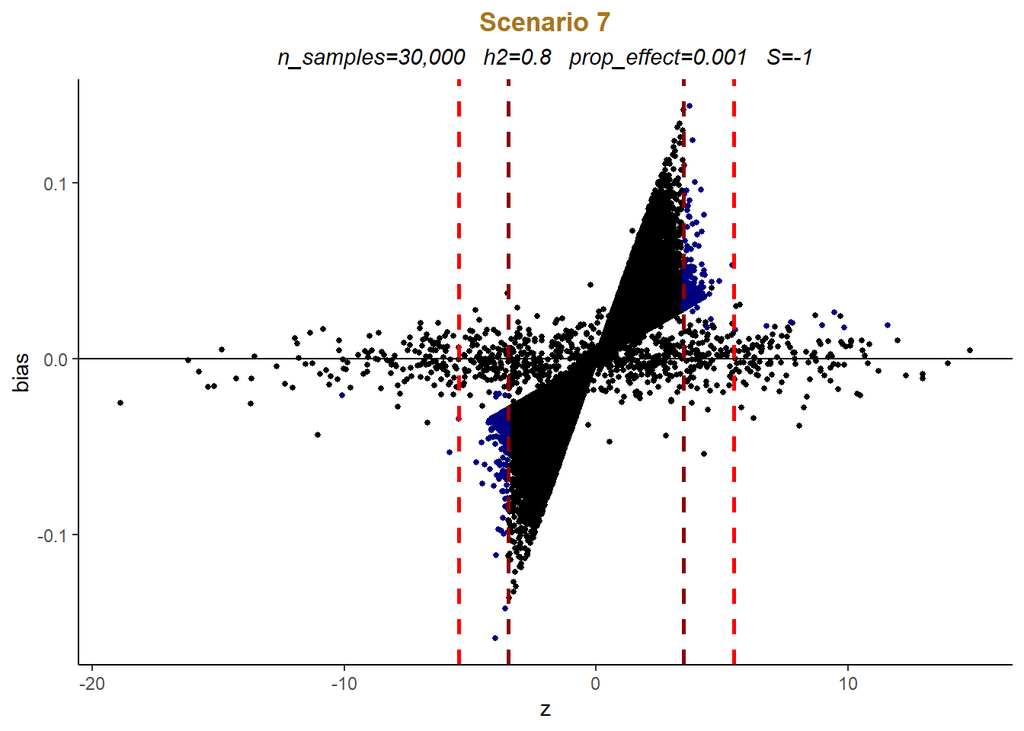

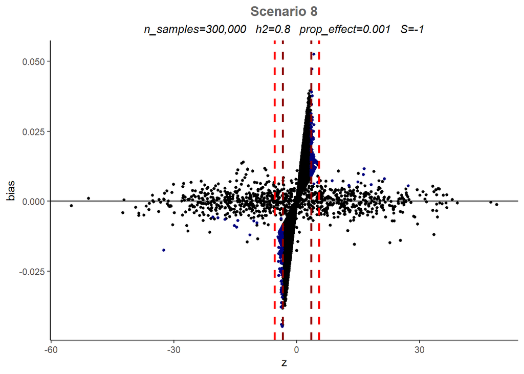

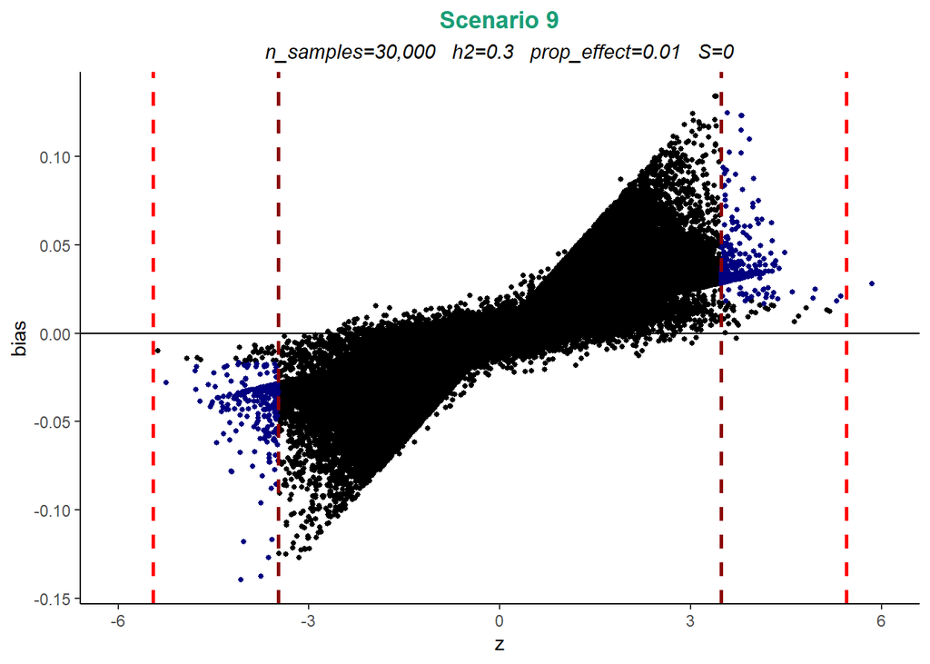

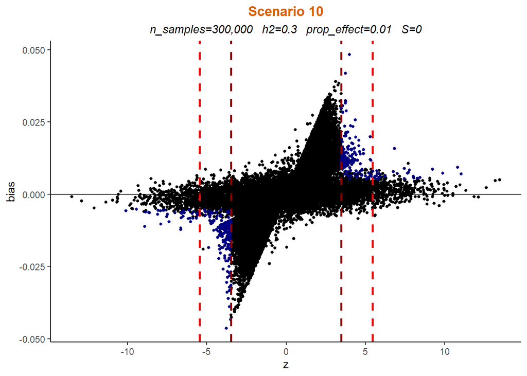

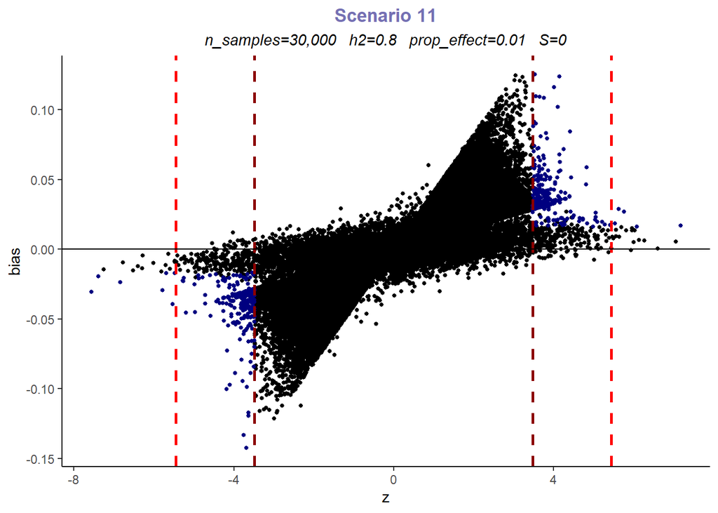

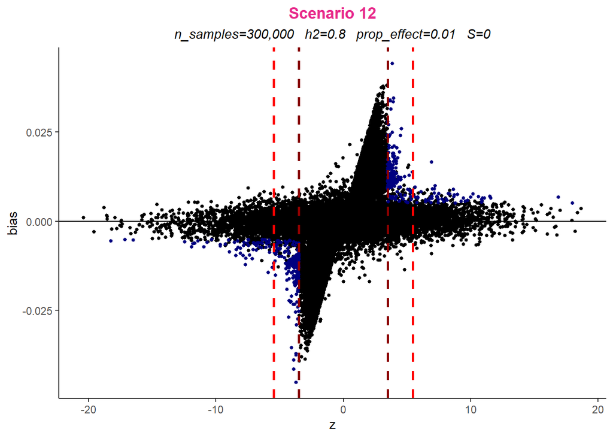

[12 more figures not shown]

### 2. Evaluating methods using a significance threshold of $5 \times 10^{-8}$

Using the code detailed in `norm_5e-8_100sim.R` and a total of 100 simulations, we evaluated six different Winner’s Curse methods across each of the 24 scenarios using the following three bias evaluation metrics:

1. The average fraction of significant SNPs in which their association estimates have been improved due to method implementation - `flb`
2. The average change in average MSE of significant SNPs due to method implementation - `mse`
3. The average *relative* change in average MSE of significant SNPs due to method implementation - `rel_mse`

**Note:** All averages are obtained over only those simulations in which at least one significant SNP was detected.

Firstly, the fraction of $n$ significant SNPs in which their association estimates have been improved due to method implementation may be mathematically described as:
$$\frac{1}{n} \; \sum_{i=1}^{n}\mathbb{I} \left\{ \left| \hat\beta_i - \beta_i \right| > \left|\hat\beta_{\text{adj,}i} - \beta_i\right| \right\},$$
in which $\left| \frac{\hat\beta_i}{\hat\sigma_i} \right| > Z_{\frac{\alpha}{2}}$ for all $i = 1,...,n$, where $\hat\beta_i$ is the estimated naive effect size of SNP $i$, $\beta_i$ is its true effect size and $\hat\beta_{\text{adj,}i}$ is its new effect size estimate obtained as a result of application of the Winner’s Curse adjustment method of interest. The significance threshold is represented by $\alpha$.

Using the same notation, the average MSE over $n$ significant SNPs is defined as:
$$\frac{1}{n} \sum^n_{i=1} (\hat\beta_i - \beta_i)^2.$$
Thus, using the above, we may formally define the change in average MSE of significant SNPs as:
$$\frac{1}{n} \sum^n_{i=1} (\hat\beta_{\text{adj,}i} - \beta_i)^2 - \frac{1}{n} \sum^n_{i=1} (\hat\beta_i - \beta_i)^2$$
and the relative change in average MSE of significant SNPs as:
$$\frac{\frac{1}{n} \sum^n_{i=1} (\hat\beta_{\text{adj,}i} - \beta_i)^2 - \frac{1}{n} \sum^n_{i=1} (\hat\beta_i - \beta_i)^2}{\frac{1}{n} \sum^n_{i=1} (\hat\beta_i - \beta_i)^2}.$$

$~$

Results of the simulations are plotted. We noted that the selection parameter, S, does not in fact have much of an impact and thus, all plots merely include those scenarios in which S is fixed at 0. Error bars are also included in the plots. These figures allow us to see more clearly the scenarios in which it would be beneficial to apply a Winner’s Curse correction method and also, provide us with a better indication of which method we should use.

A replication method which selects significant SNPs from a discovery GWAS and then uses a replication GWAS of the *same size* to obtain association estimates for these SNPs is also included in the plots. This can be viewed as acting as a form of benchmark for the other methods.

Summary of results for `flb` contained in `norm_5e-8_100sim.csv`:

| Scenario | n_samples | h2 | prop_effect | S | EB | FIQT | BR | cl1 | cl2 | cl3 | rep |
| --- | --- | --- | --- | --- | --- | --- | --- | --- | --- | --- | --- |
| 1 | 30,000 | 0.3 | 0.010 | -1 | 0.9368 | 0.9425 | 0.9253 | 0.8672 | 0.9598 | 0.9282 | 0.9655 |
| 2 | 300,000 | 0.3 | 0.010 | -1 | 0.6400 | 0.4401 | 0.6042 | 0.5311 | 0.4994 | 0.5115 | 0.5596 |
| 3 | 30,000 | 0.8 | 0.010 | -1 | 0.9126 | 0.7690 | 0.7885 | 0.6018 | 0.7255 | 0.6569 | 0.8210 |
| 4 | 300,000 | 0.8 | 0.010 | -1 | 0.5631 | 0.2815 | 0.5321 | 0.5155 | 0.4851 | 0.4995 | 0.5133 |
| 5 | 30,000 | 0.3 | 0.001 | -1 | 0.6409 | 0.3531 | 0.4920 | 0.5345 | 0.5057 | 0.5149 | 0.5606 |
| 6 | 300,000 | 0.3 | 0.001 | -1 | 0.3734 | 0.1378 | 0.2756 | 0.5076 | 0.4797 | 0.5003 | 0.5035 |
| 7 | 30,000 | 0.8 | 0.001 | -1 | 0.4576 | 0.2187 | 0.3003 | 0.5077 | 0.4798 | 0.4936 | 0.5145 |
| 8 | 300,000 | 0.8 | 0.001 | -1 | 0.3330 | 0.1014 | 0.2996 | 0.5005 | 0.4658 | 0.4875 | 0.4997 |
| 9 | 30,000 | 0.3 | 0.010 | 0 | 0.8679 | 0.9068 | 0.8398 | 0.7122 | 0.9273 | 0.8797 | 0.9725 |
| 10 | 300,000 | 0.3 | 0.010 | 0 | 0.6164 | 0.4015 | 0.5698 | 0.5237 | 0.4927 | 0.5054 | 0.5456 |
| 11 | 30,000 | 0.8 | 0.010 | 0 | 0.8378 | 0.6583 | 0.7040 | 0.5679 | 0.6363 | 0.5972 | 0.7505 |
| 12 | 300,000 | 0.8 | 0.010 | 0 | 0.5574 | 0.2730 | 0.5241 | 0.5139 | 0.4835 | 0.4986 | 0.5134 |
| 13 | 30,000 | 0.3 | 0.001 | 0 | 0.6093 | 0.3095 | 0.4540 | 0.5246 | 0.4978 | 0.5078 | 0.5467 |
| 14 | 300,000 | 0.3 | 0.001 | 0 | 0.3704 | 0.1422 | 0.2835 | 0.5087 | 0.4778 | 0.4998 | 0.5013 |
| 15 | 30,000 | 0.8 | 0.001 | 0 | 0.4512 | 0.2019 | 0.2808 | 0.5161 | 0.4845 | 0.5014 | 0.5091 |
| 16 | 300,000 | 0.8 | 0.001 | 0 | 0.3362 | 0.1076 | 0.3034 | 0.5043 | 0.4646 | 0.4856 | 0.5033 |
| 17 | 30,000 | 0.3 | 0.010 | 1 | 0.7774 | 0.8416 | 0.7599 | 0.6606 | 0.8541 | 0.7440 | 0.9382 |
| 18 | 300,000 | 0.3 | 0.010 | 1 | 0.6040 | 0.3684 | 0.5386 | 0.5246 | 0.4942 | 0.5061 | 0.5387 |
| 19 | 30,000 | 0.8 | 0.010 | 1 | 0.8015 | 0.6127 | 0.6803 | 0.5701 | 0.6104 | 0.5841 | 0.7096 |
| 20 | 300,000 | 0.8 | 0.010 | 1 | 0.5483 | 0.2581 | 0.5165 | 0.5133 | 0.4836 | 0.4991 | 0.5098 |
| 21 | 30,000 | 0.3 | 0.001 | 1 | 0.5784 | 0.2869 | 0.4321 | 0.5349 | 0.5023 | 0.5138 | 0.5428 |
| 22 | 300,000 | 0.3 | 0.001 | 1 | 0.3666 | 0.1459 | 0.2804 | 0.5032 | 0.4738 | 0.4940 | 0.5009 |
| 23 | 30,000 | 0.8 | 0.001 | 1 | 0.4441 | 0.1886 | 0.2672 | 0.5139 | 0.4869 | 0.5011 | 0.5020 |
| 24 | 300,000 | 0.8 | 0.001 | 1 | 0.3287 | 0.1133 | 0.3045 | 0.5042 | 0.4569 | 0.4792 | 0.5014 |

$~$ $~$ $~$ $~$

**Fraction of significant SNPs with improved association estimates due to method implementation, using a significance threshold of $5 \times 10^{-8}$:**

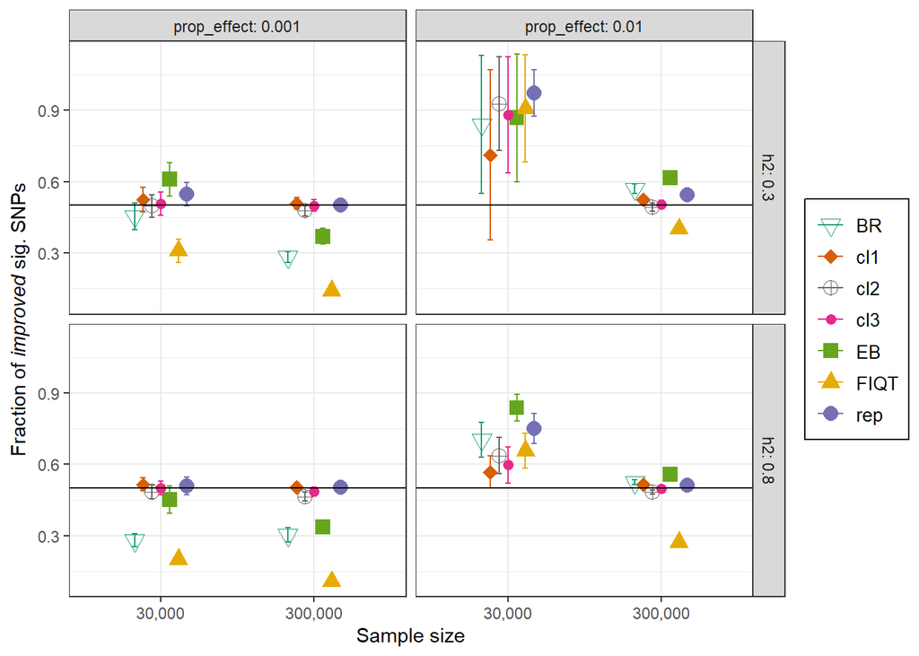

Summary of results for `mse` contained in `norm_5e-8_100sim.csv`:

| Scenario | n_samples | h2 | prop_effect | S | EB | FIQT | BR | cl1 | cl2 | cl3 | rep |
| --- | --- | --- | --- | --- | --- | --- | --- | --- | --- | --- | --- |
| 1 | 30,000 | 0.3 | 0.010 | -1 | -0.001532 | -0.001497 | -0.001496 | -0.001125 | -0.001386 | -0.001311 | -0.001509 |
| 2 | 300,000 | 0.3 | 0.010 | -1 | -0.000007 | 0.000001 | -0.000005 | 0.000052 | 0.000022 | 0.000034 | -0.000006 |
| 3 | 30,000 | 0.8 | 0.010 | -1 | -0.000447 | -0.000465 | -0.000473 | 0.000298 | -0.000300 | -0.000061 | -0.000464 |
| 4 | 300,000 | 0.8 | 0.010 | -1 | -0.000001 | 0.000005 | 0.000000 | 0.000034 | 0.000020 | 0.000025 | -0.000001 |
| 5 | 30,000 | 0.3 | 0.001 | -1 | -0.000056 | 0.000120 | 0.000045 | 0.000501 | 0.000206 | 0.000326 | -0.000055 |
| 6 | 300,000 | 0.3 | 0.001 | -1 | 0.000000 | 0.000006 | 0.000013 | 0.000014 | 0.000010 | 0.000011 | 0.000000 |
| 7 | 30,000 | 0.8 | 0.001 | -1 | -0.000004 | 0.000133 | 0.000157 | 0.000334 | 0.000197 | 0.000251 | -0.000008 |
| 8 | 300,000 | 0.8 | 0.001 | -1 | 0.000000 | 0.000004 | 0.000007 | 0.000008 | 0.000024 | 0.000011 | 0.000000 |
| 9 | 30,000 | 0.3 | 0.010 | 0 | -0.000560 | -0.000585 | -0.000541 | -0.000282 | -0.000544 | -0.000454 | -0.000604 |
| 10 | 300,000 | 0.3 | 0.010 | 0 | -0.000003 | 0.000001 | -0.000002 | 0.000026 | 0.000011 | 0.000017 | -0.000003 |
| 11 | 30,000 | 0.8 | 0.010 | 0 | -0.000155 | -0.000142 | -0.000153 | 0.000209 | -0.000061 | 0.000048 | -0.000164 |
| 12 | 300,000 | 0.8 | 0.010 | 0 | -0.000001 | 0.000002 | 0.000000 | 0.000021 | 0.000011 | 0.000015 | -0.000001 |
| 13 | 30,000 | 0.3 | 0.001 | 0 | -0.000023 | 0.000069 | 0.000036 | 0.000268 | 0.000115 | 0.000178 | -0.000029 |
| 14 | 300,000 | 0.3 | 0.001 | 0 | 0.000000 | 0.000005 | 0.000009 | 0.000014 | 0.000008 | 0.000011 | 0.000000 |
| 15 | 30,000 | 0.8 | 0.001 | 0 | -0.000005 | 0.000065 | 0.000097 | 0.000200 | 0.000108 | 0.000144 | -0.000012 |
| 16 | 300,000 | 0.8 | 0.001 | 0 | 0.000001 | 0.000004 | 0.000007 | 0.000012 | 0.000027 | 0.000014 | 0.000000 |
| 17 | 30,000 | 0.3 | 0.010 | 1 | -0.000432 | -0.000489 | -0.000449 | -0.000223 | -0.000466 | -0.000381 | -0.000534 |
| 18 | 300,000 | 0.3 | 0.010 | 1 | -0.000002 | 0.000002 | 0.000000 | 0.000022 | 0.000011 | 0.000015 | -0.000002 |
| 19 | 30,000 | 0.8 | 0.010 | 1 | -0.000114 | -0.000092 | -0.000109 | 0.000215 | -0.000014 | 0.000079 | -0.000118 |
| 20 | 300,000 | 0.8 | 0.010 | 1 | -0.000001 | 0.000002 | 0.000000 | 0.000016 | 0.000009 | 0.000012 | -0.000001 |
| 21 | 30,000 | 0.3 | 0.001 | 1 | -0.000017 | 0.000065 | 0.000041 | 0.000214 | 0.000097 | 0.000144 | -0.000024 |
| 22 | 300,000 | 0.3 | 0.001 | 1 | 0.000000 | 0.000004 | 0.000008 | 0.000011 | 0.000007 | 0.000008 | 0.000000 |
| 23 | 30,000 | 0.8 | 0.001 | 1 | -0.000002 | 0.000058 | 0.000105 | 0.000161 | 0.000090 | 0.000118 | -0.000006 |
| 24 | 300,000 | 0.8 | 0.001 | 1 | 0.000001 | 0.000003 | 0.000005 | 0.000009 | 0.000040 | 0.000015 | 0.000000 |

$~$ $~$ $~$ $~$

*Change* **in average MSE over all significant SNPs due to method implementation, using a significance threshold of $5 \times 10^{-8}$:**

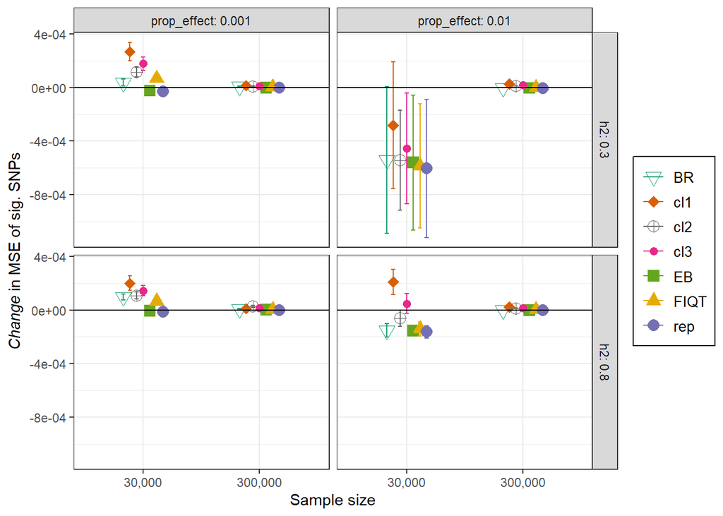

$~$ $~$ $~$ $~$

Summary of results for `rel_mse` contained in `norm_5e-8_100sim.csv`:

| Scenario | n_samples | h2 | prop_effect | S | EB | FIQT | BR | cl1 | cl2 | cl3 | rep |
| --- | --- | --- | --- | --- | --- | --- | --- | --- | --- | --- | --- |
| 1 | 30,000 | 0.3 | 0.010 | -1 | -0.7134 | -0.7599 | -0.6417 | -0.2091 | -0.7641 | -0.5594 | -0.8176 |
| 2 | 300,000 | 0.3 | 0.010 | -1 | -0.3107 | 0.0455 | -0.2213 | 2.5129 | 1.0499 | 1.6476 | -0.2602 |
| 3 | 30,000 | 0.8 | 0.010 | -1 | -0.7102 | -0.7047 | -0.7209 | 0.5887 | -0.4325 | -0.0227 | -0.7117 |
| 4 | 300,000 | 0.8 | 0.010 | -1 | -0.0873 | 0.2894 | -0.0034 | 2.0229 | 1.1931 | 1.5150 | -0.0637 |
| 5 | 30,000 | 0.3 | 0.001 | -1 | -0.2620 | 0.6378 | 0.2606 | 2.5376 | 1.0674 | 1.6646 | -0.2400 |
| 6 | 300,000 | 0.3 | 0.001 | -1 | 0.0023 | 0.4001 | 0.7969 | 0.8951 | 0.6164 | 0.7190 | -0.0154 |
| 7 | 30,000 | 0.8 | 0.001 | -1 | -0.0210 | 0.8160 | 0.9658 | 2.0479 | 1.2115 | 1.5413 | -0.0361 |
| 8 | 300,000 | 0.8 | 0.001 | -1 | 0.0306 | 0.2236 | 0.4367 | 0.5178 | 1.5449 | 0.7018 | -0.0011 |
| 9 | 30,000 | 0.3 | 0.010 | 0 | -0.5439 | -0.6014 | -0.3633 | 0.2432 | -0.6280 | -0.2924 | -0.8690 |
| 10 | 300,000 | 0.3 | 0.010 | 0 | -0.2667 | 0.0564 | -0.1580 | 2.2734 | 0.9725 | 1.5009 | -0.2791 |
| 11 | 30,000 | 0.8 | 0.010 | 0 | -0.6501 | -0.5754 | -0.6238 | 0.9423 | -0.2267 | 0.2468 | -0.6740 |
| 12 | 300,000 | 0.8 | 0.010 | 0 | -0.1035 | 0.1941 | -0.0405 | 1.9526 | 1.0837 | 1.4230 | -0.1109 |
| 13 | 30,000 | 0.3 | 0.001 | 0 | -0.1979 | 0.6592 | 0.3528 | 2.4693 | 1.0762 | 1.6453 | -0.2368 |
| 14 | 300,000 | 0.3 | 0.001 | 0 | -0.0041 | 0.4080 | 0.7704 | 1.2136 | 0.7297 | 0.9179 | -0.0261 |
| 15 | 30,000 | 0.8 | 0.001 | 0 | -0.0458 | 0.6328 | 0.9416 | 1.9160 | 1.0437 | 1.3903 | -0.0974 |
| 16 | 300,000 | 0.8 | 0.001 | 0 | 0.0451 | 0.3187 | 0.5335 | 0.9469 | 2.0873 | 1.0970 | -0.0063 |
| 17 | 30,000 | 0.3 | 0.010 | 1 | -0.4521 | -0.5980 | -0.4390 | 0.4873 | -0.5910 | -0.1640 | -0.7933 |
| 18 | 300,000 | 0.3 | 0.010 | 1 | -0.2108 | 0.1795 | -0.0422 | 2.3259 | 1.1011 | 1.5918 | -0.2125 |
| 19 | 30,000 | 0.8 | 0.010 | 1 | -0.5984 | -0.4699 | -0.5624 | 1.1842 | -0.0530 | 0.4501 | -0.6117 |
| 20 | 300,000 | 0.8 | 0.010 | 1 | -0.0758 | 0.2294 | 0.0064 | 1.8293 | 1.0377 | 1.3463 | -0.0918 |
| 21 | 30,000 | 0.3 | 0.001 | 1 | -0.1614 | 0.6925 | 0.4448 | 2.2252 | 1.0222 | 1.5083 | -0.2168 |
| 22 | 300,000 | 0.3 | 0.001 | 1 | 0.0022 | 0.3859 | 0.8303 | 1.1778 | 0.7272 | 0.8900 | -0.0270 |
| 23 | 30,000 | 0.8 | 0.001 | 1 | -0.0249 | 0.6678 | 1.1980 | 1.8405 | 1.0337 | 1.3536 | -0.0617 |
| 24 | 300,000 | 0.8 | 0.001 | 1 | 0.0536 | 0.2656 | 0.4826 | 0.8302 | 3.9174 | 1.4655 | -0.0376 |

$~$ $~$ $~$ $~$

The *mean* relative change in average MSE over all significant SNPs across the 24 scenarios is obtained for each method:

```
##         EB       FIQT         BR        cl1        cl2        cl3        rep
## -0.2210917  0.1413750  0.1751625  1.4488125  0.8258458  0.9824000 -0.2707417
```

The methods are ranked according to the results above in ascending order:

```
##   EB FIQT   BR  cl1  cl2  cl3  rep
##    2    3    4    7    5    6    1
```

$~$ $~$ $~$ $~$

*Relative change* **in average MSE over all significant SNPs due to method implementation, using a significance threshold of $5 \times 10^{-8}$:**

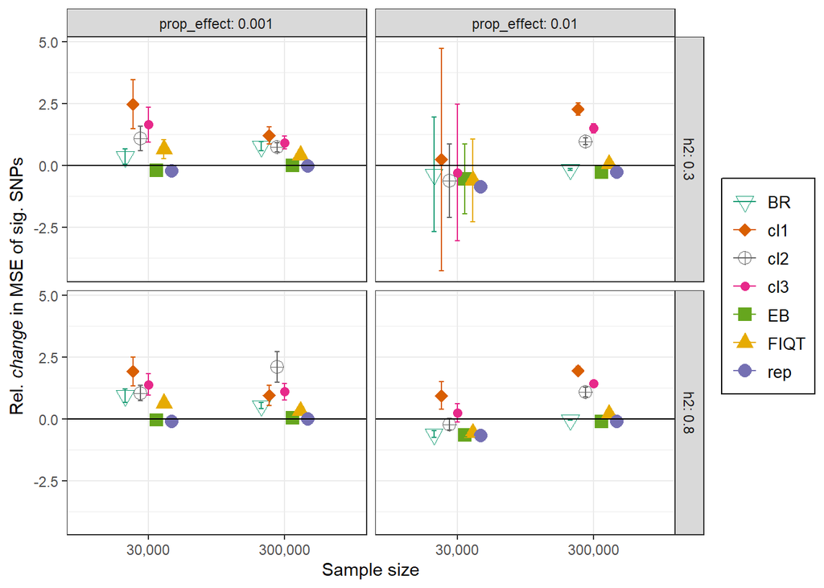

$~$ $~$ $~$ $~$

### 3. Observations and discussion of above simulations

It is worth noting from the above simulations how the Winner’s Curse methods tend to break down, or equivalently, no longer make improvements based on the third evaluation metric, `rel_mse` when the proportion of effect SNPs is 0.001. This is a measure of polygenicity. That said, the empirical Bayes method performs very similar to just taking a replication estimate when the replication sample is of the same size as the discovery GWAS, i.e. `n_samples` is equivalent in both data sets and as we will see later, the empirical Bayes will outperform the replication method when the replication GWAS sample size becomes smaller than that of the discovery, at this threshold of `5e-8`. This observation *strongly supports the use of empirical Bayes* as a Winner’s Curse adjustment method, particularly when a replication GWAS is not available. The consistency of the empirical Bayes method is what makes it stand out above the other considered methods. Unlike the bootstrap and FIQT, it is rare that it will result in an increase in the relative average MSE or average MSE over all significant SNPs. For that reason, employing this method gives us confidence that we have not adjusted our estimated effect sizes so that they are now less accurate, regardless of the underlying genetic architecture or number of samples.

For `prop_effect = 0.01`, our proposed bootstrap method for summary statistics performs in a comparable manner to both empirical Bayes and the replication method. However, the bootstrap method ceases to perform as well at obtaining less biased association estimates when the proportion of effect SNPs is reduced to 0.001.

On all occasions, the conditional likelihood methods tend to perform poorly compared to the other methods. This is likely due to the fact that the conditional likelihood approach can over-correct estimated effect sizes, especially those that lie close to the significance threshold.

Clearly, even though we also look at using a significance threshold of $5 \times 10^{-4}$, it is the genome-wide significance threshold of $5 \times 10^{-8}$ that is of most interest to us as using the higher threshold of $5 \times 10^{-4}$ often results in the detection of many false positives.

### 4. Evaluating methods using a significance threshold of $5 \times 10^{-4}$

Summary of results for `rel_mse` contained in `norm_5e-4_10sim.csv`:

| Scenario | n_samples | h2 | prop_effect | S | EB | FIQT | BR | cl1 | cl2 | cl3 | rep |
| --- | --- | --- | --- | --- | --- | --- | --- | --- | --- | --- | --- |
| 1 | 30,000 | 0.3 | 0.010 | -1 | -0.9516 | -0.9538 | -0.8959 | -0.8370 | -0.7039 | -0.7932 | -0.9216 |
| 2 | 300,000 | 0.3 | 0.010 | -1 | -0.4013 | -0.2231 | -0.2830 | -0.2135 | -0.3549 | -0.3199 | -0.6819 |
| 3 | 30,000 | 0.8 | 0.010 | -1 | -0.7634 | -0.7475 | -0.7374 | -0.6905 | -0.6600 | -0.7033 | -0.8664 |
| 4 | 300,000 | 0.8 | 0.010 | -1 | -0.2859 | -0.0602 | -0.1729 | -0.1374 | -0.2304 | -0.2131 | -0.5530 |
| 5 | 30,000 | 0.3 | 0.001 | -1 | -0.8184 | -0.7769 | -0.7278 | -0.7638 | -0.6496 | -0.7286 | -0.8955 |
| 6 | 300,000 | 0.3 | 0.001 | -1 | -0.7582 | -0.6891 | -0.5591 | -0.7297 | -0.6083 | -0.6904 | -0.8329 |
| 7 | 30,000 | 0.8 | 0.001 | -1 | -0.7888 | -0.7142 | -0.6462 | -0.7525 | -0.6325 | -0.7150 | -0.8723 |
| 8 | 300,000 | 0.8 | 0.001 | -1 | -0.7390 | -0.7006 | -0.5663 | -0.7322 | -0.4960 | -0.6632 | -0.8239 |
| 9 | 30,000 | 0.3 | 0.010 | 0 | -0.9602 | -0.9623 | -0.8920 | -0.8364 | -0.6981 | -0.7889 | -0.9228 |
| 10 | 300,000 | 0.3 | 0.010 | 0 | -0.5172 | -0.4540 | -0.4662 | -0.4573 | -0.5001 | -0.5093 | -0.7680 |
| 11 | 30,000 | 0.8 | 0.010 | 0 | -0.8003 | -0.8057 | -0.7681 | -0.7498 | -0.6698 | -0.7350 | -0.8929 |
| 12 | 300,000 | 0.8 | 0.010 | 0 | -0.3762 | -0.2532 | -0.3139 | -0.2712 | -0.3518 | -0.3419 | -0.6549 |
| 13 | 30,000 | 0.3 | 0.001 | 0 | -0.8694 | -0.8520 | -0.7850 | -0.8045 | -0.6715 | -0.7598 | -0.9124 |
| 14 | 300,000 | 0.3 | 0.001 | 0 | -0.7661 | -0.7077 | -0.5836 | -0.7417 | -0.6210 | -0.7032 | -0.8567 |
| 15 | 30,000 | 0.8 | 0.001 | 0 | -0.8080 | -0.7669 | -0.6897 | -0.7596 | -0.6432 | -0.7231 | -0.8884 |
| 16 | 300,000 | 0.8 | 0.001 | 0 | -0.7355 | -0.7030 | -0.5716 | -0.7424 | -0.4546 | -0.6598 | -0.8420 |
| 17 | 30,000 | 0.3 | 0.010 | 1 | -0.9483 | -0.9552 | -0.8843 | -0.8346 | -0.6971 | -0.7874 | -0.9221 |
| 18 | 300,000 | 0.3 | 0.010 | 1 | -0.5410 | -0.4831 | -0.4843 | -0.5187 | -0.5206 | -0.5474 | -0.7940 |
| 19 | 30,000 | 0.8 | 0.010 | 1 | -0.7916 | -0.7933 | -0.7542 | -0.7493 | -0.6628 | -0.7304 | -0.8932 |
| 20 | 300,000 | 0.8 | 0.010 | 1 | -0.4445 | -0.3419 | -0.3732 | -0.4101 | -0.4267 | -0.4454 | -0.7067 |
| 21 | 30,000 | 0.3 | 0.001 | 1 | -0.8894 | -0.8731 | -0.8004 | -0.8196 | -0.6786 | -0.7710 | -0.9139 |
| 22 | 300,000 | 0.3 | 0.001 | 1 | -0.8113 | -0.7658 | -0.6339 | -0.7680 | -0.6377 | -0.7245 | -0.8767 |
| 23 | 30,000 | 0.8 | 0.001 | 1 | -0.8456 | -0.8061 | -0.7222 | -0.7801 | -0.6548 | -0.7385 | -0.8952 |
| 24 | 300,000 | 0.8 | 0.001 | 1 | -0.7679 | -0.7470 | -0.6121 | -0.7711 | -0.4363 | -0.6760 | -0.8655 |

$~$ $~$ $~$ $~$

The *mean* relative change in average MSE over all significant SNPs across the 24 scenarios is obtained for each method:

```
##         EB       FIQT         BR        cl1        cl2        cl3        rep
## -0.7241292 -0.6723208 -0.6218042 -0.6612917 -0.5691792 -0.6445125 -0.8355375
```

The methods are ranked according to the results above in ascending order:

```
##   EB FIQT   BR  cl1  cl2  cl3  rep
##    2    3    6    4    7    5    1
```

$~$ $~$ $~$ $~$

*Relative change* **in average MSE over all significant SNPs due to method implementation, using a significance threshold of $5 \times 10^{-4}$:**

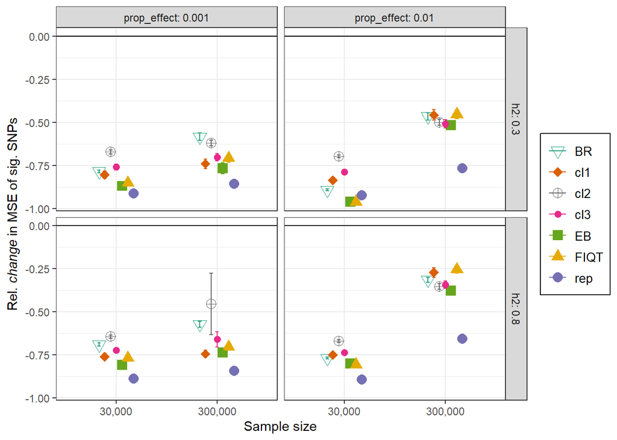

$~$ $~$ $~$ $~$

### 5. Bimodal distribution of effect sizes

A major limitation of the evaluation of methods using simulations is that informing the simulations correctly can be very difficult. For example, not all traits will have a normally distributed true effect size distribution. Therefore, in order to see if the methods perform differently when the distribution is changed, we decide to investigate the 24 different scenarios under a *bimodal* distribution of effect sizes. In order to create a bimodal distribution, we simulate 50% of effect sizes of the true effect SNPs from a normal distribution centered at 0 while the other half are generated from a normal distribution with mean 2.5. As above, we first have a look at the expected number of significant SNPs and the expected proportion of those in which their association estimate is *significantly* exaggerated.

Running the code provided in `nsig_prop_bias_100sim.R`, we obtain the following results:

| Scenario | n_samples | h2 | prop_effect | S | n_sig 5e-8 | prop_bias 5e-8 | prop_x 5e-8 | mse 5e-8 | sd(n_sig) 5e-8 | sd(prop_bias) 5e-8 | sd(prop_x) 5e-8 | sd(mse) 5e-8 |
| --- | --- | --- | --- | --- | --- | --- | --- | --- | --- | --- | --- | --- |
| 1 | 30,000 | 0.3 | 0.010 | -1 | 0.61 | 1.0000 | 0.9583 | 0.001874 | 0.803 | 0.0000 | 0.1729 | 0.003349 |
| 2 | 300,000 | 0.3 | 0.010 | -1 | 855.06 | 0.7741 | 0.0910 | 0.000016 | 19.640 | 0.0127 | 0.0090 | 0.000001 |
| 3 | 30,000 | 0.8 | 0.010 | -1 | 24.74 | 0.9968 | 0.4860 | 0.000474 | 5.181 | 0.0111 | 0.1190 | 0.000207 |
| 4 | 300,000 | 0.8 | 0.010 | -1 | 2820.65 | 0.6243 | 0.0470 | 0.000014 | 27.505 | 0.0085 | 0.0043 | 0.000001 |
| 5 | 30,000 | 0.3 | 0.001 | -1 | 85.88 | 0.7709 | 0.0882 | 0.000161 | 5.689 | 0.0503 | 0.0294 | 0.000041 |
| 6 | 300,000 | 0.3 | 0.001 | -1 | 574.45 | 0.5513 | 0.0337 | 0.000015 | 12.756 | 0.0207 | 0.0080 | 0.000002 |
| 7 | 30,000 | 0.8 | 0.001 | -1 | 281.92 | 0.6252 | 0.0475 | 0.000136 | 8.026 | 0.0287 | 0.0118 | 0.000022 |
| 8 | 300,000 | 0.8 | 0.001 | -1 | 729.09 | 0.5264 | 0.0288 | 0.000015 | 12.631 | 0.0177 | 0.0056 | 0.000001 |
| 9 | 30,000 | 0.3 | 0.010 | 0 | 0.44 | 1.0000 | 1.0000 | 0.002490 | 0.686 | 0.0000 | 0.0000 | 0.006906 |
| 10 | 300,000 | 0.3 | 0.010 | 0 | 906.91 | 0.7750 | 0.0855 | 0.000012 | 18.945 | 0.0132 | 0.0094 | 0.000001 |
| 11 | 30,000 | 0.8 | 0.010 | 0 | 22.50 | 1.0000 | 0.5724 | 0.000392 | 4.520 | 0.0000 | 0.1058 | 0.000087 |
| 12 | 300,000 | 0.8 | 0.010 | 0 | 2867.23 | 0.6130 | 0.0442 | 0.000010 | 29.528 | 0.0090 | 0.0038 | 0.000000 |
| 13 | 30,000 | 0.3 | 0.001 | 0 | 91.79 | 0.7793 | 0.0867 | 0.000120 | 6.703 | 0.0456 | 0.0286 | 0.000026 |
| 14 | 300,000 | 0.3 | 0.001 | 0 | 543.36 | 0.5426 | 0.0315 | 0.000012 | 10.686 | 0.0230 | 0.0083 | 0.000001 |
| 15 | 30,000 | 0.8 | 0.001 | 0 | 285.41 | 0.6093 | 0.0420 | 0.000101 | 9.313 | 0.0282 | 0.0111 | 0.000013 |
| 16 | 300,000 | 0.8 | 0.001 | 0 | 693.12 | 0.5289 | 0.0307 | 0.000013 | 12.186 | 0.0176 | 0.0075 | 0.000001 |
| 17 | 30,000 | 0.3 | 0.010 | 1 | 0.52 | 1.0000 | 1.0000 | 0.001402 | 0.717 | 0.0000 | 0.0000 | 0.001109 |
| 18 | 300,000 | 0.3 | 0.010 | 1 | 918.79 | 0.8193 | 0.0945 | 0.000012 | 19.846 | 0.0133 | 0.0096 | 0.000001 |
| 19 | 30,000 | 0.8 | 0.010 | 1 | 15.89 | 1.0000 | 0.7521 | 0.000474 | 3.408 | 0.0000 | 0.1188 | 0.000097 |
| 20 | 300,000 | 0.8 | 0.010 | 1 | 3130.86 | 0.6014 | 0.0392 | 0.000010 | 26.113 | 0.0098 | 0.0034 | 0.000000 |
| 21 | 30,000 | 0.3 | 0.001 | 1 | 91.90 | 0.8221 | 0.0879 | 0.000119 | 5.901 | 0.0404 | 0.0293 | 0.000023 |
| 22 | 300,000 | 0.3 | 0.001 | 1 | 521.36 | 0.5350 | 0.0309 | 0.000012 | 8.481 | 0.0212 | 0.0081 | 0.000001 |
| 23 | 30,000 | 0.8 | 0.001 | 1 | 313.57 | 0.5995 | 0.0392 | 0.000095 | 8.843 | 0.0282 | 0.0123 | 0.000010 |
| 24 | 300,000 | 0.8 | 0.001 | 1 | 628.44 | 0.5231 | 0.0298 | 0.000013 | 10.003 | 0.0184 | 0.0065 | 0.000001 |

$~$ $~$ $~$ $~$

To give an idea of what this bimodal distribution looks like, we have a look at the $z$ vs $\text{bias}$ plot for Scenarios 11 and 12.

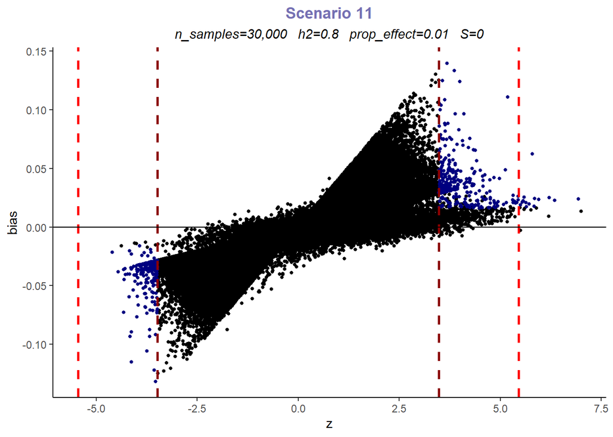

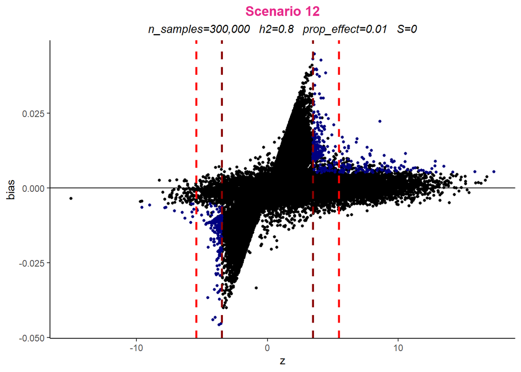

Next, we repeat the process illustrated in Section 2 using the third bias evaluation metric, `rel_mse` with a significance threshold of $5 \times 10^{-8}$.

Summary of results for `rel_mse` contained in `bimod_5e-8_100sim.csv`:

| Scenario | n_samples | h2 | prop_effect | S | EB | FIQT | BR | cl1 | cl2 | cl3 | rep |
| --- | --- | --- | --- | --- | --- | --- | --- | --- | --- | --- | --- |
| 1 | 30,000 | 0.3 | 0.010 | -1 | -0.9205 | -0.9338 | -0.9069 | -0.6777 | -0.8816 | -0.8227 | -0.9118 |
| 2 | 300,000 | 0.3 | 0.010 | -1 | -0.4011 | -0.1116 | -0.3658 | 2.4162 | 0.9195 | 1.5315 | -0.3198 |
| 3 | 30,000 | 0.8 | 0.010 | -1 | -0.8054 | -0.8519 | -0.8632 | 0.1080 | -0.6699 | -0.3655 | -0.7872 |
| 4 | 300,000 | 0.8 | 0.010 | -1 | -0.1252 | 0.2410 | -0.0707 | 2.2243 | 1.2762 | 1.6422 | -0.0783 |
| 5 | 30,000 | 0.3 | 0.001 | -1 | -0.2720 | 0.4698 | 0.0593 | 2.4294 | 0.9966 | 1.5785 | -0.3007 |
| 6 | 300,000 | 0.3 | 0.001 | -1 | 0.0015 | 0.4479 | 0.7674 | 1.1680 | 0.7811 | 0.9161 | -0.0101 |
| 7 | 30,000 | 0.8 | 0.001 | -1 | -0.0630 | 0.7435 | 0.6571 | 2.3727 | 1.2984 | 1.7334 | -0.0952 |
| 8 | 300,000 | 0.8 | 0.001 | -1 | 0.0137 | 0.2466 | 0.5897 | 0.5723 | 0.7177 | 0.5346 | -0.0173 |
| 9 | 30,000 | 0.3 | 0.010 | 0 | -0.9453 | -0.9583 | -0.9713 | -0.6880 | -0.8977 | -0.8446 | -0.9191 |
| 10 | 300,000 | 0.3 | 0.010 | 0 | -0.4004 | -0.0872 | -0.3785 | 2.4771 | 0.9910 | 1.5983 | -0.3050 |
| 11 | 30,000 | 0.8 | 0.010 | 0 | -0.8262 | -0.8562 | -0.8811 | 0.1087 | -0.6794 | -0.3733 | -0.7997 |
| 12 | 300,000 | 0.8 | 0.010 | 0 | -0.1101 | 0.2527 | -0.0999 | 2.0739 | 1.1750 | 1.5301 | -0.0889 |
| 13 | 30,000 | 0.3 | 0.001 | 0 | -0.2912 | 0.5144 | -0.0545 | 2.6142 | 1.0789 | 1.7078 | -0.3050 |
| 14 | 300,000 | 0.3 | 0.001 | 0 | -0.0121 | 0.3797 | 0.5200 | 1.1968 | 0.7029 | 0.8983 | -0.0457 |
| 15 | 30,000 | 0.8 | 0.001 | 0 | -0.0553 | 0.7642 | 0.6150 | 2.1165 | 1.2208 | 1.5772 | -0.0694 |
| 16 | 300,000 | 0.8 | 0.001 | 0 | 0.0042 | 0.2830 | 0.5415 | 0.7956 | 0.8568 | 0.7004 | -0.0150 |
| 17 | 30,000 | 0.3 | 0.010 | 1 | -0.9547 | -0.9419 | -0.9682 | -0.8230 | -0.8991 | -0.9064 | -0.9182 |
| 18 | 300,000 | 0.3 | 0.010 | 1 | -0.4911 | -0.2324 | -0.4743 | 2.5756 | 0.9328 | 1.6093 | -0.3428 |
| 19 | 30,000 | 0.8 | 0.010 | 1 | -0.8556 | -0.9223 | -0.9172 | -0.2330 | -0.7993 | -0.5878 | -0.8373 |
| 20 | 300,000 | 0.8 | 0.010 | 1 | -0.1159 | 0.3068 | -0.1152 | 2.1783 | 1.2796 | 1.6357 | -0.0658 |
| 21 | 30,000 | 0.3 | 0.001 | 1 | -0.4396 | 0.2219 | -0.2784 | 2.4985 | 0.8710 | 1.5396 | -0.3566 |
| 22 | 300,000 | 0.3 | 0.001 | 1 | -0.0102 | 0.3842 | 0.5850 | 1.0917 | 0.6626 | 0.8315 | -0.0309 |
| 23 | 30,000 | 0.8 | 0.001 | 1 | -0.0500 | 0.8052 | 0.5009 | 2.1781 | 1.2759 | 1.6328 | -0.0650 |
| 24 | 300,000 | 0.8 | 0.001 | 1 | 0.0071 | 0.3091 | 0.5566 | 0.7692 | 0.5890 | 0.6281 | 0.0342 |

$~$ $~$ $~$ $~$

The *mean* relative change in average MSE over all significant SNPs across the 24 scenarios is obtained for each method:

```
##          EB        FIQT          BR         cl1         cl2         cl3
## -0.33826667  0.01976667 -0.08136250  1.31430833  0.53328333  0.83021250
##         rep
## -0.31877500
```

The methods are ranked according to the results above in ascending order:

```
##   EB FIQT   BR  cl1  cl2  cl3  rep
##    1    4    3    7    5    6    2
```

$~$ $~$ $~$ $~$

*Relative change* **in average MSE over all significant SNPs due to method implementation, using a significance threshold of $5 \times 10^{-8}$ and a** *bimodal* **distribution of effect sizes:**

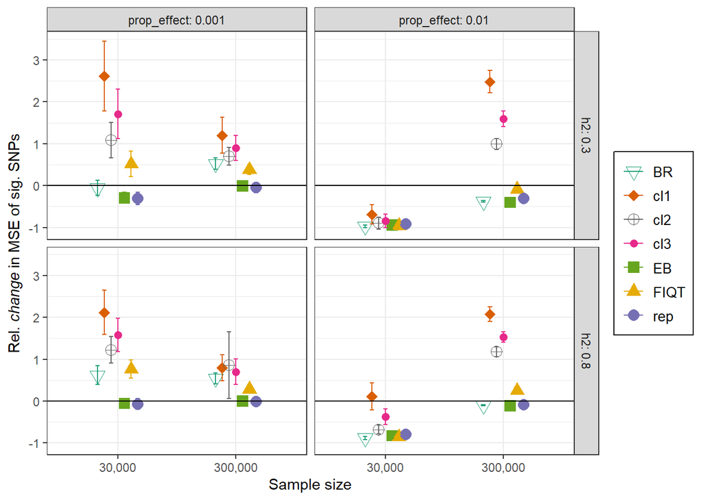

$~$ $~$ $~$ $~$

We see that the empirical Bayes method continues to perform well under this distribution of true effect sizes, with it even outperforming using replication estimates in some instances. Our proposed bootstrap method behaves very competitively when the proportion of true effect SNPs is 0.01. Again, the simulations suggest that the conditional likelihood methods should not be employed to assist in reducing the bias induced by winner’s curse.

### 6. Skewed distribution of effect sizes

Next we investigate the 24 different scenarios under a *skewed* distribution of effect sizes. Details for the manner in which this skewed distribution is simulated may be found in `useful_funs.R` with the function named `simulate_ss_exp`. As above, we first have a look at the expected number of significant SNPs and the expected proportion of those in which their association estimate is *significantly* exaggerated.

Running the code provided in `nsig_prop_bias_100sim.R`, we obtain the following results:

| Scenario | n_samples | h2 | prop_effect | S | n_sig 5e-8 | prop_bias 5e-8 | prop_x 5e-8 | mse 5e-8 | sd(n_sig) 5e-8 | sd(prop_bias) 5e-8 | sd(prop_x) 5e-8 | sd(mse) 5e-8 |
| --- | --- | --- | --- | --- | --- | --- | --- | --- | --- | --- | --- | --- |
| 1 | 30,000 | 0.3 | 0.010 | -1 | 29.72 | 0.7588 | 0.1277 | 0.000156 | 4.221 | 0.0868 | 0.0782 | 0.000064 |
| 2 | 300,000 | 0.3 | 0.010 | -1 | 711.56 | 0.6607 | 0.0652 | 0.000012 | 25.810 | 0.0161 | 0.0098 | 0.000001 |
| 3 | 30,000 | 0.8 | 0.010 | -1 | 140.00 | 0.7201 | 0.0962 | 0.000136 | 8.965 | 0.0373 | 0.0269 | 0.000023 |
| 4 | 300,000 | 0.8 | 0.010 | -1 | 1718.82 | 0.6136 | 0.0488 | 0.000012 | 55.461 | 0.0118 | 0.0052 | 0.000001 |
| 5 | 30,000 | 0.3 | 0.001 | -1 | 71.68 | 0.6525 | 0.0641 | 0.000126 | 8.579 | 0.0533 | 0.0288 | 0.000038 |
| 6 | 300,000 | 0.3 | 0.001 | -1 | 373.57 | 0.5644 | 0.0368 | 0.000012 | 20.125 | 0.0253 | 0.0100 | 0.000001 |
| 7 | 30,000 | 0.8 | 0.001 | -1 | 173.44 | 0.6166 | 0.0481 | 0.000121 | 15.630 | 0.0376 | 0.0172 | 0.000025 |
| 8 | 300,000 | 0.8 | 0.001 | -1 | 533.86 | 0.5416 | 0.0324 | 0.000013 | 21.914 | 0.0223 | 0.0081 | 0.000001 |
| 9 | 30,000 | 0.3 | 0.010 | 0 | 12.23 | 0.8877 | 0.2712 | 0.000242 | 3.741 | 0.0941 | 0.1175 | 0.000126 |
| 10 | 300,000 | 0.3 | 0.010 | 0 | 844.43 | 0.6714 | 0.0656 | 0.000011 | 19.523 | 0.0157 | 0.0081 | 0.000001 |
| 11 | 30,000 | 0.8 | 0.010 | 0 | 121.68 | 0.7890 | 0.1297 | 0.000149 | 8.836 | 0.0381 | 0.0325 | 0.000025 |
| 12 | 300,000 | 0.8 | 0.010 | 0 | 2049.74 | 0.6101 | 0.0468 | 0.000011 | 33.493 | 0.0117 | 0.0047 | 0.000001 |
| 13 | 30,000 | 0.3 | 0.001 | 0 | 84.53 | 0.6747 | 0.0644 | 0.000113 | 5.913 | 0.0517 | 0.0280 | 0.000027 |
| 14 | 300,000 | 0.3 | 0.001 | 0 | 424.36 | 0.5574 | 0.0341 | 0.000012 | 16.164 | 0.0250 | 0.0081 | 0.000001 |
| 15 | 30,000 | 0.8 | 0.001 | 0 | 205.02 | 0.6042 | 0.0486 | 0.000110 | 12.765 | 0.0325 | 0.0159 | 0.000016 |
| 16 | 300,000 | 0.8 | 0.001 | 0 | 579.08 | 0.5362 | 0.0316 | 0.000013 | 16.364 | 0.0204 | 0.0077 | 0.000001 |
| 17 | 30,000 | 0.3 | 0.010 | 1 | 16.85 | 0.8815 | 0.2186 | 0.000216 | 3.729 | 0.0654 | 0.0965 | 0.000122 |
| 18 | 300,000 | 0.3 | 0.010 | 1 | 823.78 | 0.6592 | 0.0630 | 0.000011 | 21.028 | 0.0154 | 0.0081 | 0.000001 |
| 19 | 30,000 | 0.8 | 0.010 | 1 | 133.51 | 0.7765 | 0.1159 | 0.000142 | 7.247 | 0.0348 | 0.0244 | 0.000035 |
| 20 | 300,000 | 0.8 | 0.010 | 1 | 1933.35 | 0.6073 | 0.0466 | 0.000011 | 31.170 | 0.0105 | 0.0049 | 0.000000 |
| 21 | 30,000 | 0.3 | 0.001 | 1 | 83.62 | 0.6696 | 0.0640 | 0.000110 | 6.983 | 0.0496 | 0.0273 | 0.000024 |
| 22 | 300,000 | 0.3 | 0.001 | 1 | 399.48 | 0.5608 | 0.0348 | 0.000012 | 16.905 | 0.0249 | 0.0091 | 0.000001 |
| 23 | 30,000 | 0.8 | 0.001 | 1 | 193.39 | 0.6096 | 0.0455 | 0.000109 | 11.989 | 0.0352 | 0.0158 | 0.000017 |
| 24 | 300,000 | 0.8 | 0.001 | 1 | 553.13 | 0.5393 | 0.0333 | 0.000013 | 14.653 | 0.0211 | 0.0077 | 0.000001 |

$~$ $~$ $~$ $~$

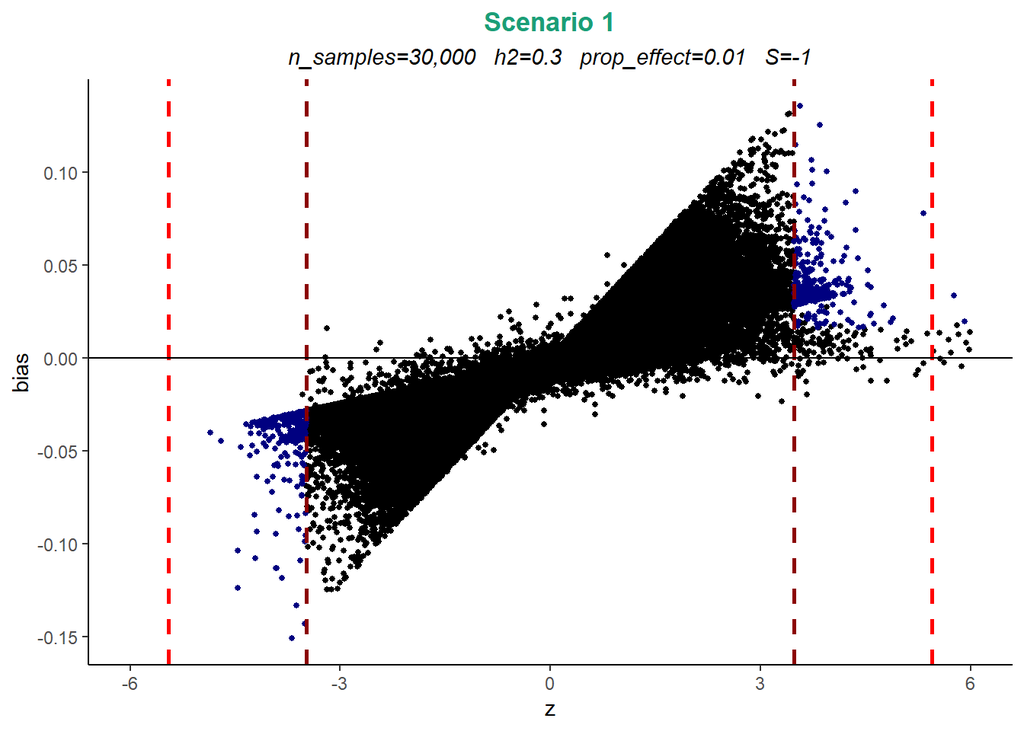

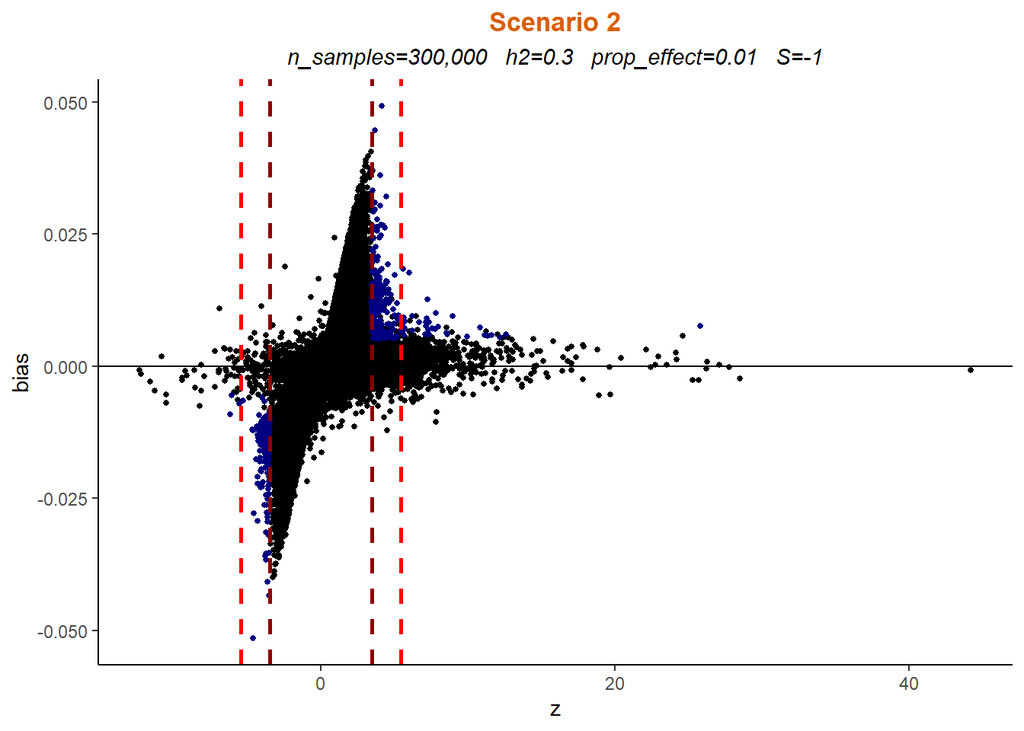

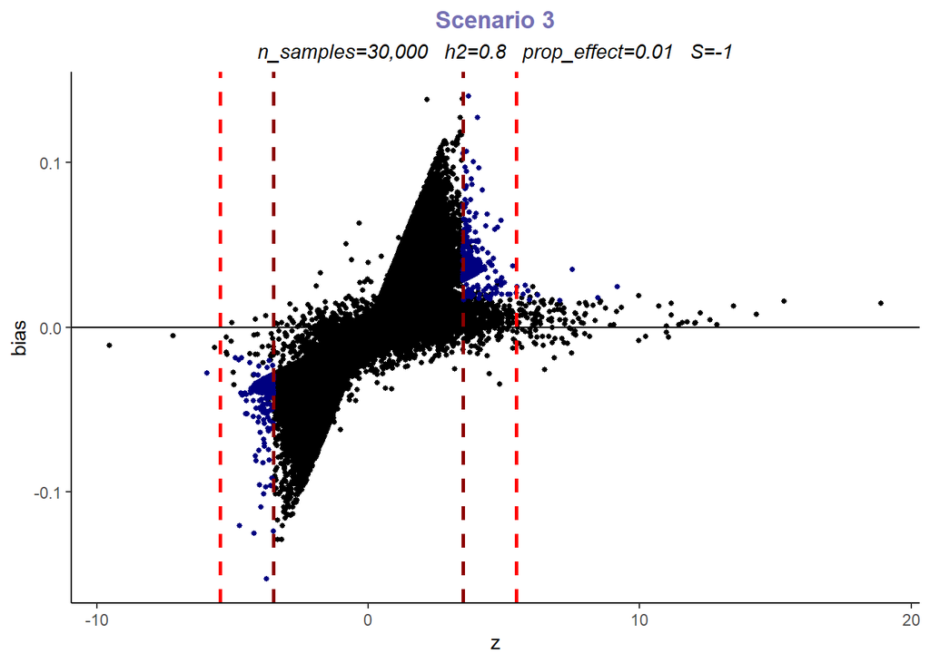

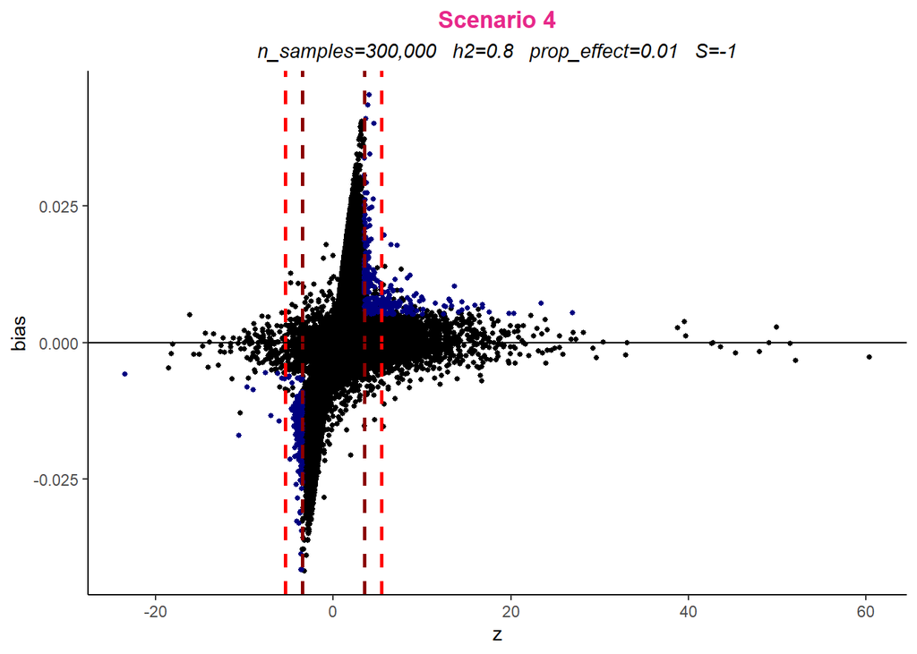

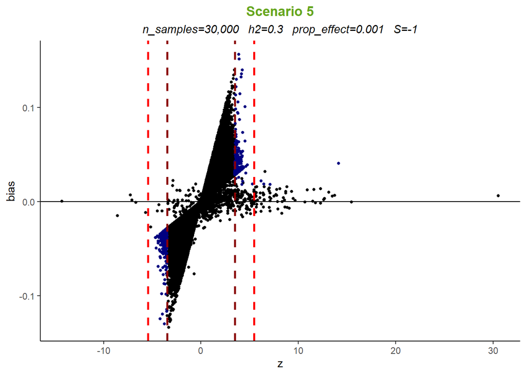

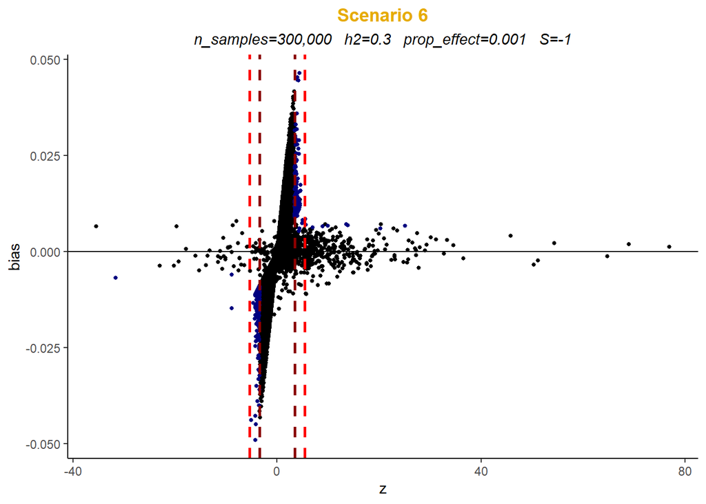

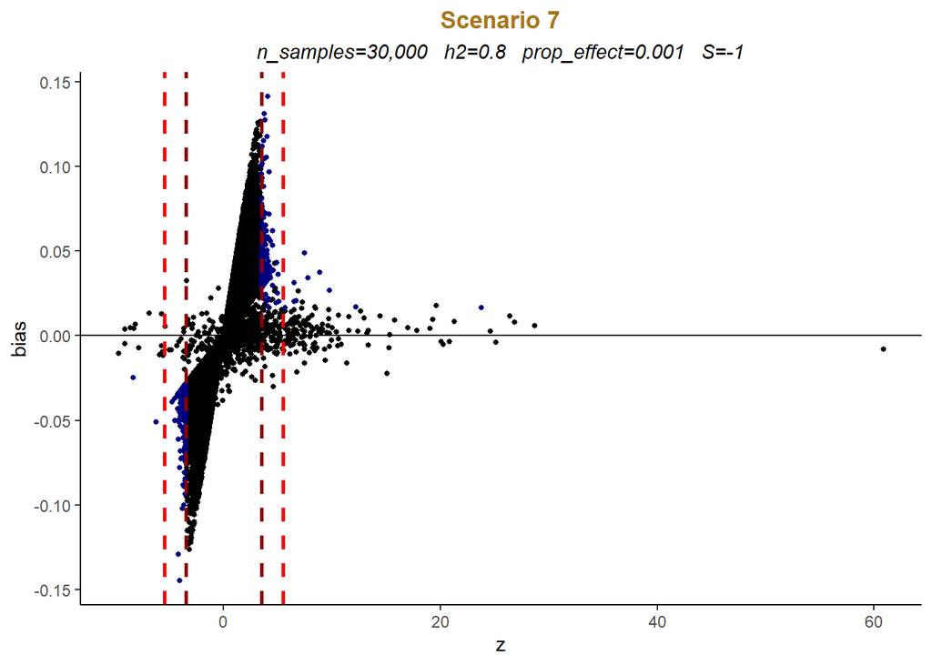

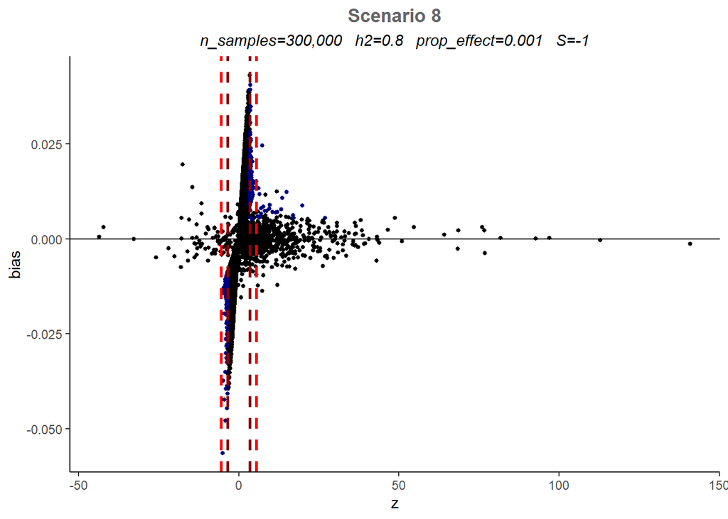

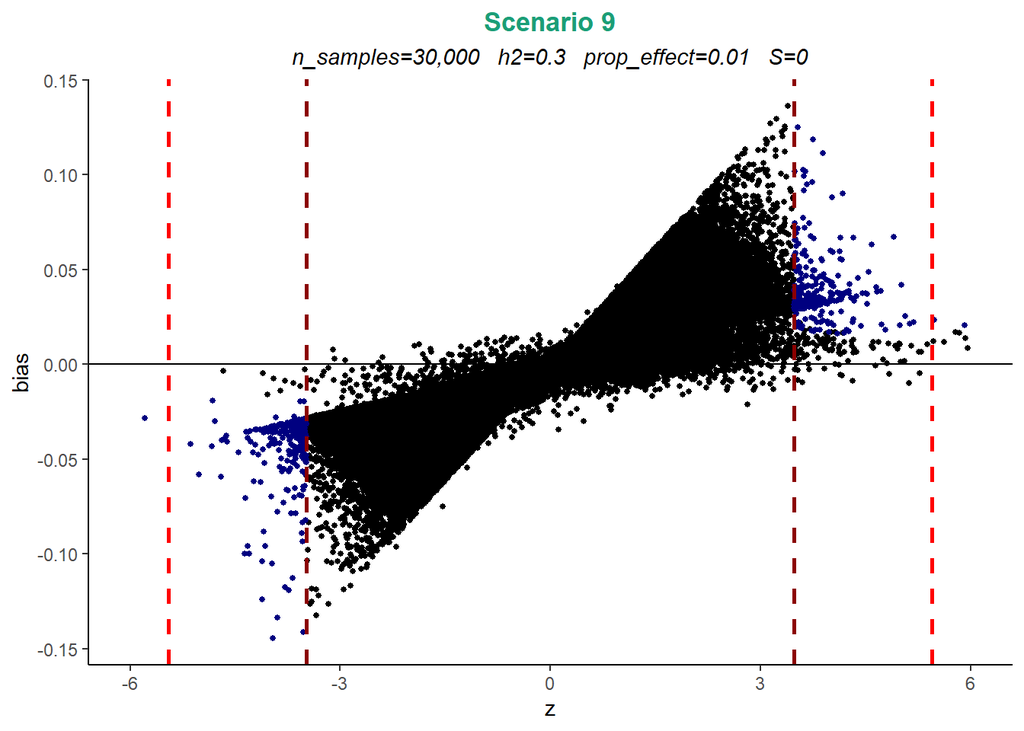

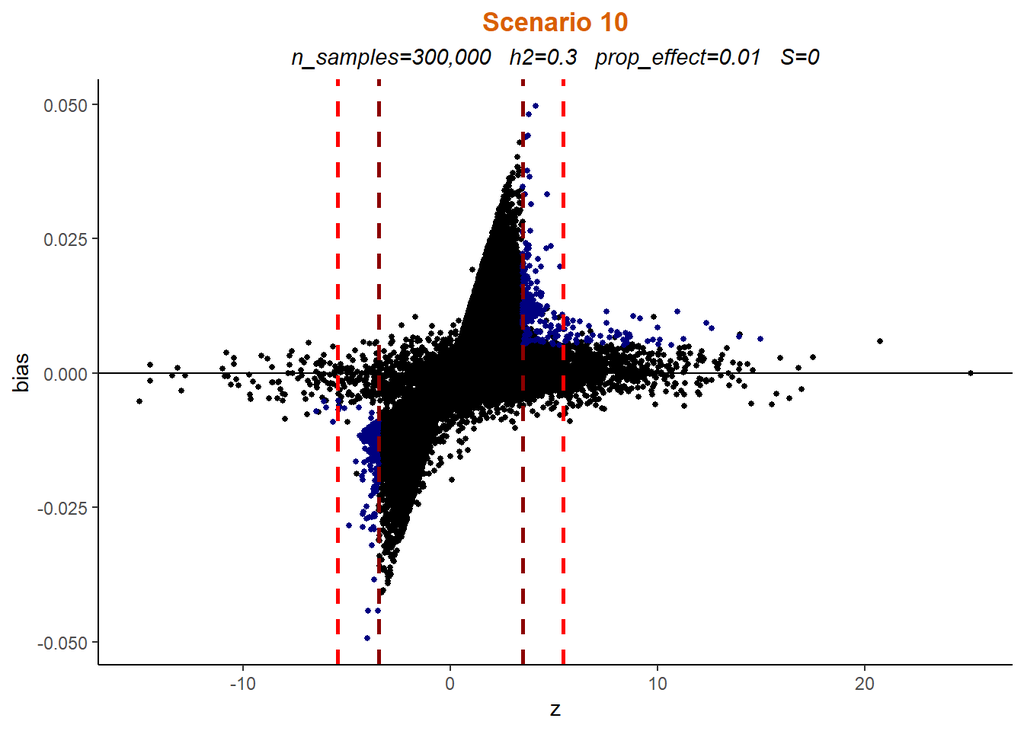

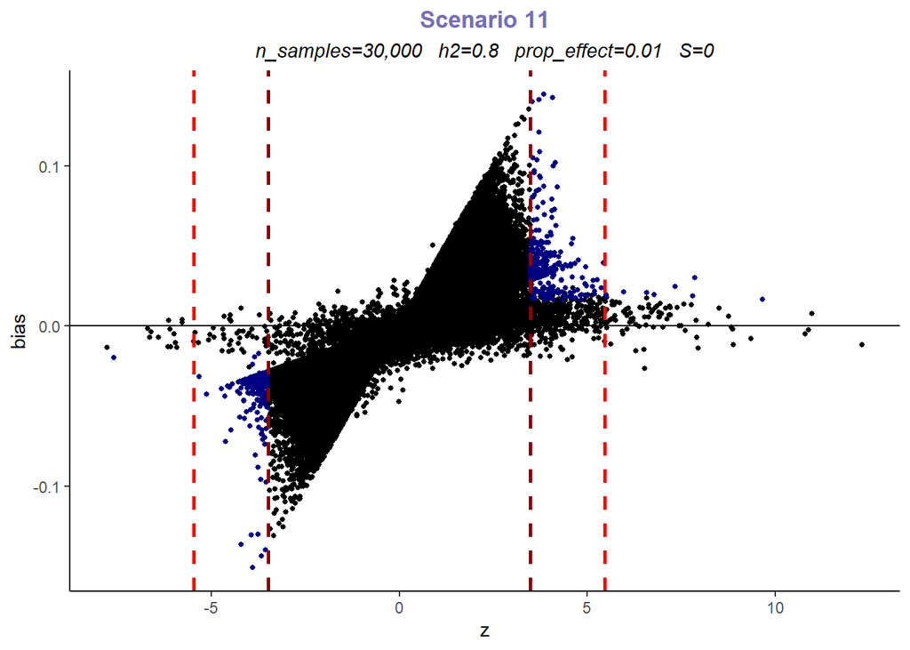

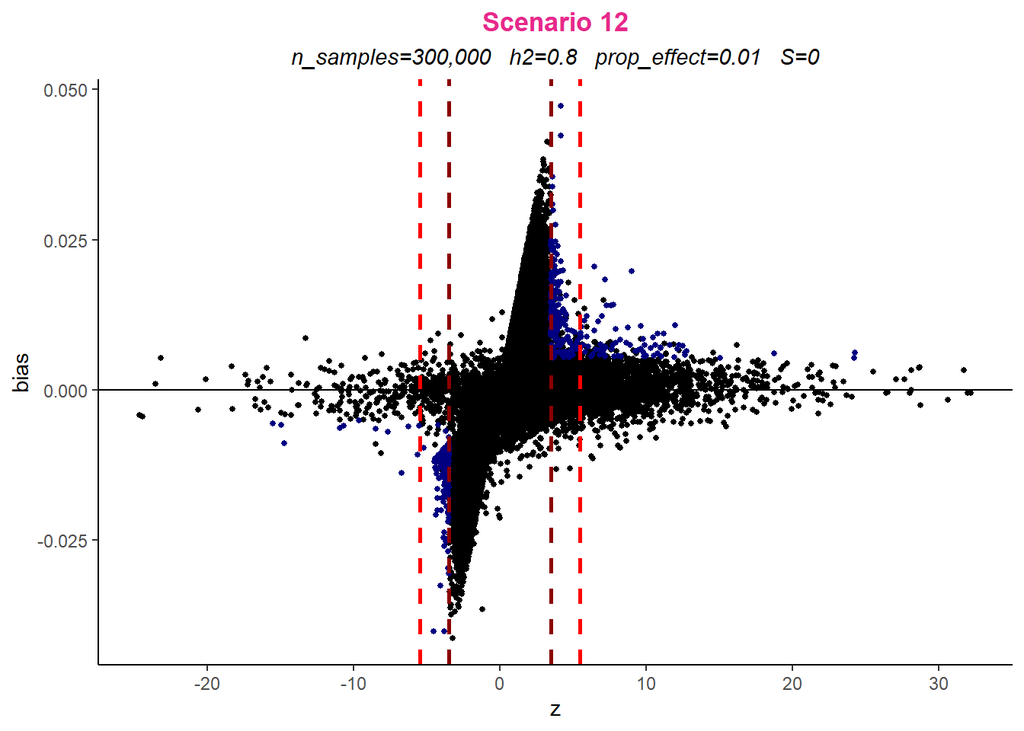

[12 more figures not shown]

$~$ $~$ $~$ $~$

Next, we repeat the process illustrated in Section 2 using the third bias evaluation metric, `rel_mse` with a significance threshold of $5 \times 10^{-8}$.

Summary of results for `rel_mse` contained in `skew_exp_5e-8_100sim.csv`:

| Scenario | n_samples | h2 | prop_effect | S | EB | FIQT | BR | cl1 | cl2 | cl3 | rep |
| --- | --- | --- | --- | --- | --- | --- | --- | --- | --- | --- | --- |
| 1 | 30,000 | 0.3 | 0.010 | -1 | -0.2608 | 0.5160 | 0.2993 | 1.7899 | 0.5661 | 1.0587 | -0.3636 |
| 2 | 300,000 | 0.3 | 0.010 | -1 | -0.1408 | 0.2121 | 0.0178 | 1.8936 | 0.9301 | 1.3071 | -0.1891 |
| 3 | 30,000 | 0.8 | 0.010 | -1 | -0.1443 | 0.2387 | 0.2099 | 1.7737 | 0.6280 | 1.0909 | -0.3245 |
| 4 | 300,000 | 0.8 | 0.010 | -1 | -0.0822 | 0.1964 | 0.1326 | 1.7123 | 1.2618 | 1.3146 | -0.1201 |
| 5 | 30,000 | 0.3 | 0.001 | -1 | 0.1468 | 0.6572 | 1.3573 | 1.9374 | 0.8882 | 1.3070 | -0.2140 |
| 6 | 300,000 | 0.3 | 0.001 | -1 | -0.0178 | 0.4191 | 0.7787 | 1.2460 | 3.5886 | 1.6412 | -0.0310 |
| 7 | 30,000 | 0.8 | 0.001 | -1 | -0.0301 | 0.6183 | 1.0659 | 1.7522 | 1.3576 | 1.3649 | -0.0938 |
| 8 | 300,000 | 0.8 | 0.001 | -1 | 0.0621 | 0.3541 | 0.8714 | 1.0293 | 9.5713 | 3.0073 | -0.0145 |
| 9 | 30,000 | 0.3 | 0.010 | 0 | -0.4304 | -0.0577 | -0.0587 | 1.4179 | 0.0384 | 0.6023 | -0.5945 |
| 10 | 300,000 | 0.3 | 0.010 | 0 | -0.1632 | 0.1982 | -0.0061 | 2.0533 | 0.9789 | 1.4073 | -0.1948 |
| 11 | 30,000 | 0.8 | 0.010 | 0 | -0.3674 | 0.0253 | -0.1872 | 1.8004 | 0.5122 | 1.0358 | -0.4207 |
| 12 | 300,000 | 0.8 | 0.010 | 0 | -0.0813 | 0.1974 | 0.0516 | 1.7561 | 1.0035 | 1.2837 | -0.1055 |
| 13 | 30,000 | 0.3 | 0.001 | 0 | 0.0033 | 0.7154 | 0.8470 | 2.0938 | 0.9765 | 1.4278 | -0.1972 |
| 14 | 300,000 | 0.3 | 0.001 | 0 | -0.0109 | 0.4272 | 0.7290 | 1.3083 | 1.6337 | 1.1934 | -0.0466 |
| 15 | 30,000 | 0.8 | 0.001 | 0 | -0.0304 | 0.5970 | 1.0371 | 1.8299 | 0.9729 | 1.3144 | -0.0903 |
| 16 | 300,000 | 0.8 | 0.001 | 0 | 0.0357 | 0.3085 | 0.6570 | 1.4644 | 7.9938 | 2.6741 | -0.0204 |
| 17 | 30,000 | 0.3 | 0.010 | 1 | -0.3729 | -0.0379 | -0.0349 | 1.2398 | 0.0293 | 0.5156 | -0.5652 |
| 18 | 300,000 | 0.3 | 0.010 | 1 | -0.1466 | 0.2258 | 0.0543 | 2.0180 | 0.9739 | 1.3947 | -0.1832 |
| 19 | 30,000 | 0.8 | 0.010 | 1 | -0.3137 | 0.1325 | -0.0787 | 1.8741 | 0.6127 | 1.1259 | -0.3813 |
| 20 | 300,000 | 0.8 | 0.010 | 1 | -0.0737 | 0.1984 | 0.0588 | 1.7188 | 0.9645 | 1.2521 | -0.0982 |
| 21 | 30,000 | 0.3 | 0.001 | 1 | -0.0048 | 0.7725 | 0.9937 | 2.0784 | 1.0111 | 1.4455 | -0.1468 |
| 22 | 300,000 | 0.3 | 0.001 | 1 | -0.0093 | 0.4351 | 0.7500 | 1.2812 | 2.2253 | 1.3217 | -0.0183 |
| 23 | 30,000 | 0.8 | 0.001 | 1 | -0.0217 | 0.6255 | 1.1724 | 1.7976 | 0.9768 | 1.3025 | -0.0768 |
| 24 | 300,000 | 0.8 | 0.001 | 1 | 0.0334 | 0.3071 | 0.6053 | 1.7853 | 9.3670 | 3.0940 | -0.0325 |

$~$ $~$ $~$ $~$

The *mean* relative change in average MSE over all significant SNPs across the 24 scenarios is obtained for each method:

```
##         EB       FIQT         BR        cl1        cl2        cl3        rep
## -0.1008750  0.3450917  0.4718125  1.6938208  2.0442583  1.4367708 -0.1884542
```

The methods are ranked according to the results above in ascending order:

```
##   EB FIQT   BR  cl1  cl2  cl3  rep
##    2    3    4    6    7    5    1
```

$~$ $~$ $~$ $~$

*Relative change* **in average MSE over all significant SNPs due to method implementation, using a significance threshold of $5 \times 10^{-8}$ and a** *skewed* **distribution of effect sizes:**

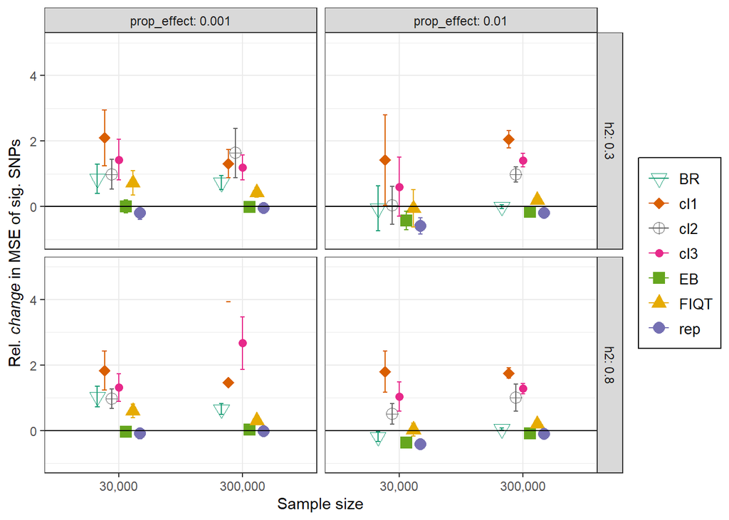

$~$ $~$ $~$ $~$